# Table of Contents (Jupyter)

• GITHUB LINK FOR EASY VIEWING OF .ipynb NOTEBOOK  
• 1.0 Understanding the Problem and the Data  
• About Ola  
• Objective of this Exercise  
• Dataset  
• 2.0 Import and Inspect the Data  
• 2.2 Statistical summary for numerical columns and Unique values for categorical data  
• 2.3 Adding insights about columns and data size.  
• 2.4 Data Dictionary  
• 2.5 Handling Missing Values  
• 2.5.1 Imputation for LastWorkingDate  
• 2.5.1 Imputation for Age and Gender  
• Deciding value of K for KNNImputer  
• 2.6 Date columns conversion  
• 2.7 Feature Engineering - Possible candidates for new features after going through existing columns  
• Group at driver id level  
• 2.7.1 Adding IncomeCAGR, IncomeLast  
• 2.7.2 Adding IncomeIncreased  
• 2.7.3 Adding GradeIncreased  
• 2.7.4 Adding RatingMean, RatingTrend, RatingTrendCode, Ratings (array)  
• 2.7.5 Adding Churn  
• 2.7.6 Adding EmploymentAge in months  
• 3.0 Explore Data Characteristics  
• 3.1 Univariate Analysis (Analysis of one attribute at a time.)  
• Helper functions  
• drawDetailedBoxPlot  
• annotate_bars  
• univariate_ordinal_analysis  
• univariate_numerical_analysis  
• make_normal  
• Driver_ID  
• Age  
• Gender  
• Education_Level  
• Dateofjoining  
• Seasonality Analysis (Which months are busiest overall?)  
• LastWorkingDate  
• Joining Designation  
• Grade  
• Total Business Value  
• Categorize drivers based on TBV  
• Analysing positive values  
• Analyzing Zero Values  
• Quarterly Rating  
• RatingMean  
• RatingTrend  
• IncomeCAGR  
• IncomeLast  
• IncomeIncreased  
• GradeIncreased  
• Churn  
• EmploymentAge  
• City  
• 3.2 Multivariate Analysis  
• Reusable helper function for ANOVA/KRUSKAL to compare categorical and numerical columns  
• Reusable helper function for chi square independence test for comparing categorical columns  
• Reusable helper function for checking relation between two numerical columns and an optional categorical column.  
• 3.2.1 Age and Churn  
• 3.2.2 Age and Gender  
• 3.2.3 Age and City  
• 3.2.4 Age and Education Level  
• 3.2.5 Age and Joining Designation  
• 3.2.6 Age and Current Grade  
• 3.2.7 Age and Rating Trend  
• 3.2.8 Age and Total Business Value  
• 3.2.9 Age and IncomeLast  
• 3.2.10 Age and RatingMean  
• 3.2.11 Driver Age and EmploymentAge  
• 3.2.12 Gender and City  
• 3.2.13 Gender and Education_Level  
• 3.2.14 Gender and Date of Joining  
• 3.2.15 Gender and LastWorkingDate  
• 3.2.16 Gender and Joining Designation  
• 3.2.17 Gender and Joining Grade  
• 3.2.18 Gender and GradeIncreased  
• 3.2.19 Gender and Total Business Value  
• 3.2.20 Gender and Quarterly Rating  
• 3.2.21 Gender and Income  
• 3.2.22 Gender and Rating  
• 3.2.23 Gender and RatingTrend  
• 3.2.24 Gender and Churn  
• 3.2.25 Gender and EmploymentAge  
• 3.2.26 JoiningDate and LastWorkingDate  
• 3.2.27 Churn and City  
• Analyse join and churn trend across cities  
• Focus on top cities  
• 3.2.28 Churn and Education Level  
• 3.2.29 Churn and Date of Joining  
• 3.2.30 Churn and Joining Designation  
• 3.2.31 Churn and Grade  
• 3.2.32 Churn and Total Business value  
• 3.2.33 Churn and Quarterly Rating  
• 3.2.34 Churn and RatingTrend  
• 3.2.35 Churn and IncomeIncreased  
• 3.2.36 Churn and GradeIncreased  
• 3.2.37 City and Education_Level  
• 3.2.38 City and IncomeIncreased  
• 3.2.39 City and IncomeLast  
• 3.2.40 City and Total Business Value  
• 3.2.40 City and Grade  
• 3.2.41 City and EmploymentAge  
• 3.2.42 Education_Level and IncomeLast  
• 3.2.43 Education_Level and IncomeIncreased  
• 3.2.44 Education_Level and GradeIncreased  
• 3.2.44 Education_Level and RatingTrend  
• 4.0 Data Preprocessing  
• 5.0 Fitting a Machine Learning Model on the data to predict churn  
• 5.1 Prepare the data  
• 5.1.1 Group Data  
• 5.1.2 Train Test Split  
• 5.2 Quick Checks on data - PCA to see separatability, VIF to see collinearity  
• 5.2.1 Access the preproceesor output and use PCA to quickly visualize data  
• 5.2.2 Use PCA to compress to 3 dimensions, where we can rotate as well  
• 5.2.3 Feature Selection using VIF score checking for Multicollinearity  
• 5.3 Fitting ALL models without hyperparam tuning, VIF and imbalance fix  
• Lets create reusable code to build the model and store results  
• Fitting Logistic  
• Fitting Random Forest  
• Fitting GBM  
• Fitting XGBoost  
• Fitting LGBM  
• Discussion: What metrics are most important for us  
• 5.4 Lets handle class imbalance  
• Logistic Untuned SMOTE  
• RandomForest Untuned SMOTE  
• RandomForest Untuned ADASYN  
• LightGBM Untuned class_weight  
• LightGBM Untuned is_unbalance  
• XGBoost Untuned SMOTE  
• XGBoost Untuned scale_pos_weight  
• Discussion : Is using Model trained on Imbalanced Data always bad?  
• 5.5 Lets see if Removing collinear features can further improve results  
• Logistic VIF imbalanced  
• RandomForest VIF Imbalanced  
• GradientBoosting VIF Imbalanced  
• 5.6 Hyper parameter tuning  
• 5.6.1 Create a Weighted-F2 scorer  
• 5.6.2 Tuning Logistic Regression  
• 5.4.2.2 Doing a manual+visual search for C Parameter  
• 5.4.2.2 Lets try polynomial regression too  
• 5.6.3 Tuning Random Forest  
• 5.6.5 Tuning Gradient Boosting (GBM)  
• 5.6.6 Tuning XGBoost  
• 5.6.7 Tuning LightGBM  
• 5.6.8 Tuning Naive Bayes  
• 5.6.9 Tuning SVC Linear  
• 5.6.10 Tuning SVC checking for all kernels  
• 5.6.11 - Tuning Linear SVM  
• 5.7 - Tuning Thresholds  
• 5.7.1 Find best thresholds for each of the top models  
• 5.7.2 Creating Models based on best thresholds.  
• 5.8 Comparison of Model Results  
• 5.8.1 Choose the candidates  
• 5.8.2 Precision Recall Curve  
• 5.8.3 Choosing the best model  
• 5.8.3.1 Testing for assumptions for SVCLinear Model  
• 5.8.3.2 Testing for assumptions for Logistic Regression  
• 5.8.3.3 Testing for assumptions for XGBoost  
• 5.8.3.4 Testing for assumptions for Random Forest  
• 5.8.3.5 Final Choice  
• 5.8.3 Feature × Model Matrix to compare features  
• 5.9 Final Model analysis  
• 5.9.1 Problem Summary  
• 5.9.2 Data Summary  
• 5.9.3 Model Selection Process  
• 5.10 🧮 Model Performance Summary — XGBoost Tuned VIF Imbalanced (Threshold = 0.3)  
• Classification Report  
• ROC AUC Curve  
• 🧭 **Interpretation — ROC–AUC Curve (XGBoost)**  
• **1️⃣ Overall Model Quality**  
• **2️⃣ Shape of the Curve**  
• **3️⃣ Trade‑off Interpretation**  
• **4️⃣ Business Implication**  
• **✅ Summary**  
• 🌳 Feature Importance – XGBoost Tuned VIF Imbalanced (Threshold = 0.3)  
• 6. Actionable Insights & Recommendations  
• 6.1 Summary of Observations from EDA  
• 6.2 Insights from EDA  
• 6.3 **Insights from the Learned Model and Their Effects**  
• **Model Interpretation Summary**  
• 6.4 Conclusions  
• 6.4.1 📊 **Conclusions from Exploratory Data Analysis (EDA)**  
• 🧩 **Overall Attrition Profile**  
• 🏙️ **City‑Level Patterns**  
• 🎓 **Joining Designation & Grade**  
• 💰 **Income & Compensation**  
• 📈 **Performance (Ratings & Trends)**  
• 💼 **Business Value Contribution**  
• 👥 **Demographics**  
• 🎯 **Hiring and Tenure Trends**  
• 🎓 **Education Patterns**  
• 💡 **Summary**  
• 6.4.2 **Conclusion from Model Interpretation**  
• 6.5 🧭 **Recommendations**  
• **1. Compensation & Growth**  
• **2. Performance Management**  
• **3. Targeted Retention Programs**  
• **4. City‑Specific Action**  
• **5. Data & Measurement**  
• **6. Workforce Strategy**  
• 6.6 Questionnaire  
• 6.6.1. What percentage of drivers have received a quarterly rating of 5?  
• 6.6.2. Comment on the correlation between Age and Quarterly Rating.  
• 6.6.3. Name the city which showed the most improvement in Quarterly Rating over the past year  
• 6.6.4. Drivers with a Grade of ‘A’ are more likely to have a higher Total Business Value. (T/F)  
• 6.6.5. If a driver's Quarterly Rating drops significantly, how does it impact their Total Business Value in the subsequent period?  
• 6.6.6. From Ola's perspective, which metric should be the primary focus for driver retention?  
• 6.6.7. How does the gap in precision and recall affect Ola's relationship with its drivers and customers?  
• 6.6.8. Besides the obvious features like Number of Rides, which lesser-discussed features might have a strong impact on a driver's Quarterly Rating?  
• 6.6.9. Will the driver's performance be affected by the City they operate in? (Yes/No)  
• 6.6.10. Analyze any seasonality in the driver's ratings. Do certain times of the year correspond to higher or lower ratings, and why might that be?  
• 6.7 Improving the model - Additional data that can be collected which can enable Ola give more insights on its drivers and customers

| These are insights got from analysing the data, in Pink color |
| --- |
| ''' ''' code sections are notes to self, some quick code snippets, or some notes while doing analysis |

## GITHUB LINK FOR EASY VIEWING OF .ipynb NOTEBOOK

**Please note, when converting to PDF, the links in TOC stop working. You may like to see the original report's .ipynb file. Please see it on my Github Repository here **

https://raw.githubusercontent.com/amitguptaforwork/dataanalytics_portfolio_projects/blob/main/CaseStudyOla_ChurnPrediction_UsingBaggingBoosting/Ola_AmitG.ipynb

https://github.com/amitguptaforwork/dataanalytics_portfolio_projects/blob/main/CaseStudyOla_ChurnPrediction_UsingBaggingBoosting/Ola_AmitG.ipynb

# 1.0 Understanding the Problem and the Data

## About Ola

Ola is an Indian ride-hailing company that connects passengers with drivers through its mobile app for cabs, auto-rickshaws, and bikes.

## Objective of this Exercise

Recruiting and retaining drivers is seen by industry watchers as a tough battle for Ola. Churn among drivers is high and it’s very easy for drivers to stop working for the service on the fly or jump to Uber depending on the rates.

As the companies get bigger, the high churn could become a bigger problem. To find new drivers, Ola is casting a wide net, including people who don’t have cars for jobs. But this acquisition is really costly. Losing drivers frequently impacts the morale of the organization and acquiring new drivers is more expensive than retaining existing ones.

This case study will focus on predicting whether a driver will be leaving the company or not based on their attributes.

Company is collecting data for the drivers on monthly basis and thus has not only static data (driver id, driver education, gender) but also dynamic data like income, grade, total business value. These attributes offer additional insight into the "professional journey" of the driver.

**Given a set of attributes for an OLA driver, determine if they may potentially leave the company**

## Dataset

The company collected the data of drivers. The dataset has the following features:

Column Profiling:

- MMMM-YY : Reporting Date (Monthly)
- Driver_ID : Unique id for drivers
- Age : Age of the driver
- Gender : Gender of the driver – Male : 0, Female: 1
- City : City Code of the driver
- Education_Level : Education level – 0 for 10+ ,1 for 12+ ,2 for graduate
- Income : Monthly average Income of the driver
- Date Of Joining : Joining date for the driver
- LastWorkingDate : Last date of working for the driver
- Joining Designation : Designation of the driver at the time of joining
- Grade : Grade of the driver at the time of reporting
- Total Business Value : The total business value acquired by the driver in a month (negative business indicates cancellation/refund or car EMI adjustments)
- Quarterly Rating : Quarterly rating of the driver: 1,2,3,4,5 (higher is better)

# 2.0 Import and Inspect the Data

```python
import pandas as pd
import matplotlib.pyplot as plt
import seaborn as sns
import numpy as np
import scipy.stats as stats
```

```python
'''
Notes to Self
During this step, looking into the statistics is critical to gain initial know-how of its structure, variable kinds, and capability issues.

'''
```

```
' \nNotes to Self\nDuring this step, looking into the statistics is critical to gain initial know-how of its structure, variable kinds, and capability issues.\n\n'
```

```python
df =pd.read_csv("ola_driver_scaler.csv")
df.columns
```

```
Index(['Unnamed: 0', 'MMM-YY', 'Driver_ID', 'Age', 'Gender', 'City',
       'Education_Level', 'Income', 'Dateofjoining', 'LastWorkingDate',
       'Joining Designation', 'Grade', 'Total Business Value',
       'Quarterly Rating'],
      dtype='object')
```

```python
#we dont need 'Unnamed: 0' column, as its just row index.
df.drop(columns=['Unnamed: 0'], inplace=True)
df
```

|  | MMM-YY | Driver_ID | Age | Gender | City | Education_Level | Income | Dateofjoining | LastWorkingDate | Joining Designation | Grade | Total Business Value | Quarterly Rating |
| --- | --- | --- | --- | --- | --- | --- | --- | --- | --- | --- | --- | --- | --- |
| 0 | 01/01/19 | 1 | 28.0 | 0.0 | C23 | 2 | 57387 | 24/12/18 | NaN | 1 | 1 | 2381060 | 2 |
| 1 | 02/01/19 | 1 | 28.0 | 0.0 | C23 | 2 | 57387 | 24/12/18 | NaN | 1 | 1 | -665480 | 2 |
| 2 | 03/01/19 | 1 | 28.0 | 0.0 | C23 | 2 | 57387 | 24/12/18 | 03/11/19 | 1 | 1 | 0 | 2 |
| 3 | 11/01/20 | 2 | 31.0 | 0.0 | C7 | 2 | 67016 | 11/06/20 | NaN | 2 | 2 | 0 | 1 |
| 4 | 12/01/20 | 2 | 31.0 | 0.0 | C7 | 2 | 67016 | 11/06/20 | NaN | 2 | 2 | 0 | 1 |
| ... | ... | ... | ... | ... | ... | ... | ... | ... | ... | ... | ... | ... | ... |
| 19099 | 08/01/20 | 2788 | 30.0 | 0.0 | C27 | 2 | 70254 | 06/08/20 | NaN | 2 | 2 | 740280 | 3 |
| 19100 | 09/01/20 | 2788 | 30.0 | 0.0 | C27 | 2 | 70254 | 06/08/20 | NaN | 2 | 2 | 448370 | 3 |
| 19101 | 10/01/20 | 2788 | 30.0 | 0.0 | C27 | 2 | 70254 | 06/08/20 | NaN | 2 | 2 | 0 | 2 |
| 19102 | 11/01/20 | 2788 | 30.0 | 0.0 | C27 | 2 | 70254 | 06/08/20 | NaN | 2 | 2 | 200420 | 2 |
| 19103 | 12/01/20 | 2788 | 30.0 | 0.0 | C27 | 2 | 70254 | 06/08/20 | NaN | 2 | 2 | 411480 | 2 |

19104 rows × 13 columns

## 2.2 Statistical summary for numerical columns and Unique values for categorical data

- Instead of manually creating tables and collecting values lets automate the table creation
- We will generate a table of all columns in Markdown format
- We will paste this table into a markdown cell and then we may add additional analysis

```python
#!pip install tabulate
from tabulate import tabulate
def generate_markdown_table_with_details(df):
    column_details = []
    for col in df.columns:
        dtype = str(df[col].dtype)

        if dtype == 'object' or dtype=='category':
            cat_or_num = 'Categorical'
            details = df[col].unique().tolist()
            if(len(details)>10):
                details= f'{df[col].nunique()} unique values.Ex.{",".join([str(x) for x in details[:3]])}'

        else:
            cat_or_num = 'Numerical'
            details = f"Min: {df[col].min()}, Max: {df[col].max()}"
        column_details.append([col, dtype, cat_or_num, details, ''])

    # Create a DataFrame for the table
    table_df = pd.DataFrame(column_details, columns=['Column Name', 'Data Type', 'Categorical or Numerical', 'Details', 'Business Description(fill manually)'])

    # Convert DataFrame to Markdown
    markdown_table = tabulate(table_df, headers='keys', tablefmt='pipe', showindex=False)
    return markdown_table

markdown_table = generate_markdown_table_with_details(df)
print(f'There are a total of {df.shape[0]:,} rows and {df.shape[1]} columns')
print(markdown_table)
```

```
There are a total of 19,104 rows and 13 columns
| Column Name          | Data Type   | Categorical or Numerical   | Details                                         | Business Description(fill manually)   |
|:---------------------|:------------|:---------------------------|:------------------------------------------------|:--------------------------------------|
| MMM-YY               | object      | Categorical                | 24 unique values.Ex.01/01/19,02/01/19,03/01/19  |                                       |
| Driver_ID            | int64       | Numerical                  | Min: 1, Max: 2788                               |                                       |
| Age                  | float64     | Numerical                  | Min: 21.0, Max: 58.0                            |                                       |
| Gender               | float64     | Numerical                  | Min: 0.0, Max: 1.0                              |                                       |
| City                 | object      | Categorical                | 29 unique values.Ex.C23,C7,C13                  |                                       |
| Education_Level      | int64       | Numerical                  | Min: 0, Max: 2                                  |                                       |
| Income               | int64       | Numerical                  | Min: 10747, Max: 188418                         |                                       |
| Dateofjoining        | object      | Categorical                | 869 unique values.Ex.24/12/18,11/06/20,12/07/19 |                                       |
| LastWorkingDate      | object      | Categorical                | 493 unique values.Ex.nan,03/11/19,27/04/20      |                                       |
| Joining Designation  | int64       | Numerical                  | Min: 1, Max: 5                                  |                                       |
| Grade                | int64       | Numerical                  | Min: 1, Max: 5                                  |                                       |
| Total Business Value | int64       | Numerical                  | Min: -6000000, Max: 33747720                    |                                       |
| Quarterly Rating     | int64       | Numerical                  | Min: 1, Max: 4                                  |                                       |
```

## 2.3 Adding insights about columns and data size.

- We will copy the markdown table generated above and add our inputs by analysing the columns.
- We identify which columns are numerical, which are categorical
- Within categorical, we identify if it is nominal or ordinal data. This helps us to decide best graph to use
- Also ordinal data can be converted into numeric using codes thereby making it available for some kind of graphs.

## 2.4 Data Dictionary

There are a total of 19,104 rows and 13 columns

Column Name

Data Type

Categorical or Numerical

Details

Business Description(fill manually)

MMM-YY

object

Categorical

24 unique values.Ex.01/01/19,02/01/19,03/01/19

Reporting Date (Monthly)

Driver_ID

int64

Numerical

Min: 1, Max: 2788

Unique id for drivers

Age

float64

Numerical

Min: 21.0, Max: 58.0

Age of the driver

Gender

float64

Numerical

Min: 0.0, Max: 1.0

Gender of the driver – Male : 0, Female: 1

City

object

Categorical

29 unique values.Ex.C23,C7,C13

City Code of the driver

Education_Level

int64

Numerical

Min: 0, Max: 2

Education level – 0 for 10+ ,1 for 12+ ,2 for graduate

Income

int64

Numerical

Min: 10747, Max: 188418

Monthly average Income of the driver

Dateofjoining

object

Categorical

869 unique values.Ex.24/12/18,11/06/20,12/07/19

Joining date for the driver

LastWorkingDate

object

Categorical

493 unique values.Ex.nan,03/11/19,27/04/20

Last date of working for the driver

Joining Designation

int64

Numerical

Min: 1, Max: 5

Designation of the driver at the time of joining

Grade

int64

Numerical

Min: 1, Max: 5

Grade of the driver at the time of reporting

Total Business Value

int64

Numerical

Min: -6000000, Max: 33747720

The total business value acquired by the driver in a month (negative business indicates cancellation/refund or car EMI adjustments. This isn't just a simple revenue column; it's more like a "Net Value Generated by Driver for the Platform" metric )

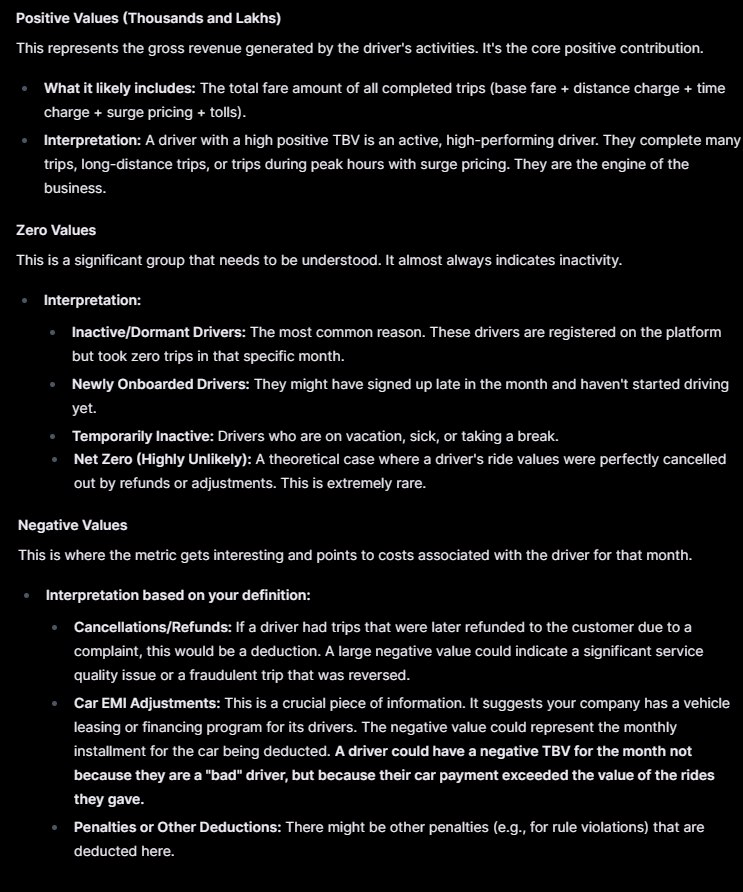

Quarterly Rating

int64

Numerical

Min: 1, Max: 4

Quarterly rating of the driver: 1,2,3,4,5 (higher is better)

19104 records

## 2.5 Handling Missing Values

Now let's check if there are any missing values in our dataset or not.

```python
'''
Notes to Self
Missing Data can also refer to as NA(Not Available) values in pandas. There are several useful functions for detecting, removing, and replacing null values in Pandas DataFrame :

isnull()
notnull()
dropna()
fillna()
replace()
interpolate()
'''
```

```
' \nNotes to Self\nMissing Data can also refer to as NA(Not Available) values in pandas. There are several useful functions for detecting, removing, and replacing null values in Pandas DataFrame :\n\nisnull()\nnotnull()\ndropna()\nfillna()\nreplace()\ninterpolate()\n'
```

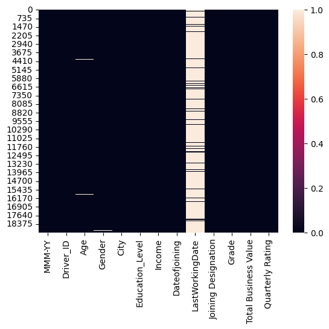

```python
sns.heatmap(df.isnull())
```

Age and Gender have a few missing values, LastWorkingDay has many, as it indicates drivers who are still there with the company.

```python
#Create a small dataframe with count of missing values, and their percentage when compared to overall data
df_analysis = pd.DataFrame(df.isnull().sum(), columns=['NumberOfMissingValues'])
df_analysis['Percentage'] = np.round(df_analysis.NumberOfMissingValues*100/len(df),1).astype(int)

#Print only columns that have any missing data
df_analysis[df_analysis.NumberOfMissingValues>0]
```

|  | NumberOfMissingValues | Percentage |
| --- | --- | --- |
| Age | 61 | 0 |
| Gender | 52 | 0 |
| LastWorkingDate | 17488 | 91 |

We have 3 columns with some missing data

LastWorkingDate missing means the driver is still with the company.

### 2.5.1 Imputation for LastWorkingDate

- We can fill some predefined value here. Later we can compare with that value to identify that this driver is still with the compaany.
- We use SimpleImputer instead of direct Pandas code (fillna)
- SimpleImputer ensures consistent, reusable, and pipeline-friendly imputations across training, testing, and production, unlike direct pandas.fillna()

```python
from sklearn.impute import SimpleImputer
#Pandas to_datetime interprets two-digit years (%y) using a "pivot year" rule:
# Years 00–68 → 2000–2068
# Years 69–99 → 1969–1999
# So we choose 2067 so that it will get converted to 2067
imp_missing = SimpleImputer(strategy='constant', fill_value="31/12/67")
df[['LastWorkingDate']] = imp_missing.fit_transform(df[['LastWorkingDate']])
```

```python
df
```

|  | MMM-YY | Driver_ID | Age | Gender | City | Education_Level | Income | Dateofjoining | LastWorkingDate | Joining Designation | Grade | Total Business Value | Quarterly Rating |
| --- | --- | --- | --- | --- | --- | --- | --- | --- | --- | --- | --- | --- | --- |
| 0 | 01/01/19 | 1 | 28.0 | 0.0 | C23 | 2 | 57387 | 24/12/18 | 31/12/67 | 1 | 1 | 2381060 | 2 |
| 1 | 02/01/19 | 1 | 28.0 | 0.0 | C23 | 2 | 57387 | 24/12/18 | 31/12/67 | 1 | 1 | -665480 | 2 |
| 2 | 03/01/19 | 1 | 28.0 | 0.0 | C23 | 2 | 57387 | 24/12/18 | 03/11/19 | 1 | 1 | 0 | 2 |
| 3 | 11/01/20 | 2 | 31.0 | 0.0 | C7 | 2 | 67016 | 11/06/20 | 31/12/67 | 2 | 2 | 0 | 1 |
| 4 | 12/01/20 | 2 | 31.0 | 0.0 | C7 | 2 | 67016 | 11/06/20 | 31/12/67 | 2 | 2 | 0 | 1 |
| ... | ... | ... | ... | ... | ... | ... | ... | ... | ... | ... | ... | ... | ... |
| 19099 | 08/01/20 | 2788 | 30.0 | 0.0 | C27 | 2 | 70254 | 06/08/20 | 31/12/67 | 2 | 2 | 740280 | 3 |
| 19100 | 09/01/20 | 2788 | 30.0 | 0.0 | C27 | 2 | 70254 | 06/08/20 | 31/12/67 | 2 | 2 | 448370 | 3 |
| 19101 | 10/01/20 | 2788 | 30.0 | 0.0 | C27 | 2 | 70254 | 06/08/20 | 31/12/67 | 2 | 2 | 0 | 2 |
| 19102 | 11/01/20 | 2788 | 30.0 | 0.0 | C27 | 2 | 70254 | 06/08/20 | 31/12/67 | 2 | 2 | 200420 | 2 |
| 19103 | 12/01/20 | 2788 | 30.0 | 0.0 | C27 | 2 | 70254 | 06/08/20 | 31/12/67 | 2 | 2 | 411480 | 2 |

19104 rows × 13 columns

### 2.5.1 Imputation for Age and Gender

- Let us observe the rows that have missing age. We want to observe if we have missing data for same driver or different drivers.
- We have a hypothesis that if its randomly missing data (MCAR - missing completely at random), then we may have different driver ids.
- The final purpose is, we know we have multiple rows per driver. So if we can establish that driver ids in missing data rows are different, it gives us a chance to copy the missing cells from other rows of the same driver.

```python
df[df.Age.isna()]
```

|  | MMM-YY | Driver_ID | Age | Gender | City | Education_Level | Income | Dateofjoining | LastWorkingDate | Joining Designation | Grade | Total Business Value | Quarterly Rating |
| --- | --- | --- | --- | --- | --- | --- | --- | --- | --- | --- | --- | --- | --- |
| 72 | 02/01/20 | 20 | NaN | 1.0 | C19 | 0 | 40342 | 25/10/19 | 31/12/67 | 3 | 3 | 0 | 1 |
| 97 | 10/01/19 | 22 | NaN | 0.0 | C10 | 2 | 31224 | 25/05/18 | 31/12/67 | 1 | 1 | 200000 | 3 |
| 110 | 07/01/19 | 24 | NaN | 0.0 | C24 | 2 | 76308 | 25/05/18 | 31/12/67 | 1 | 2 | 203240 | 3 |
| 212 | 11/01/19 | 40 | NaN | 0.0 | C15 | 0 | 59182 | 11/08/19 | 31/12/67 | 2 | 2 | 0 | 1 |
| 261 | 05/01/19 | 49 | NaN | 0.0 | C20 | 0 | 53039 | 25/05/18 | 31/12/67 | 1 | 2 | 124190 | 1 |
| ... | ... | ... | ... | ... | ... | ... | ... | ... | ... | ... | ... | ... | ... |
| 18395 | 05/01/20 | 2690 | NaN | 0.0 | C11 | 2 | 77662 | 17/07/18 | 31/12/67 | 1 | 2 | 692600 | 4 |
| 18722 | 08/01/20 | 2730 | NaN | 1.0 | C16 | 2 | 69924 | 07/08/19 | 31/12/67 | 2 | 2 | 161860 | 2 |
| 18780 | 03/01/19 | 2738 | NaN | 0.0 | C17 | 0 | 23068 | 09/08/18 | 31/12/67 | 1 | 1 | 639780 | 3 |
| 18843 | 01/01/19 | 2751 | NaN | 0.0 | C17 | 2 | 53115 | 11/05/15 | 31/12/67 | 1 | 1 | 506550 | 3 |
| 19024 | 02/01/19 | 2774 | NaN | 0.0 | C15 | 1 | 42313 | 21/07/18 | 31/12/67 | 1 | 1 | 1141280 | 4 |

61 rows × 13 columns

Indeed, the hypothesis seems to hold - the drivers are different for the missing age rows. Lets "look" at two drivers' rows to further confirm our hypothesis.

```python
df[(df.Driver_ID==167)|(df.Driver_ID==179)]
```

|  | MMM-YY | Driver_ID | Age | Gender | City | Education_Level | Income | Dateofjoining | LastWorkingDate | Joining Designation | Grade | Total Business Value | Quarterly Rating |
| --- | --- | --- | --- | --- | --- | --- | --- | --- | --- | --- | --- | --- | --- |
| 1103 | 01/01/19 | 167 | NaN | 0.0 | C18 | 1 | 35283 | 03/02/18 | 31/12/67 | 1 | 1 | 0 | 2 |
| 1104 | 02/01/19 | 167 | 26.0 | 0.0 | C18 | 1 | 35283 | 03/02/18 | 31/12/67 | 1 | 1 | 100740 | 2 |
| 1105 | 03/01/19 | 167 | 26.0 | 0.0 | C18 | 1 | 35283 | 03/02/18 | 31/12/67 | 1 | 1 | 1053880 | 2 |
| 1106 | 04/01/19 | 167 | 26.0 | 0.0 | C18 | 1 | 35283 | 03/02/18 | 31/12/67 | 1 | 1 | 0 | 1 |
| 1107 | 05/01/19 | 167 | 26.0 | 0.0 | C18 | 1 | 35283 | 03/02/18 | 05/06/19 | 1 | 1 | 0 | 1 |
| 1207 | 01/01/19 | 179 | 26.0 | 1.0 | C11 | 2 | 24490 | 26/05/18 | 31/12/67 | 1 | 1 | 203420 | 2 |
| 1208 | 02/01/19 | 179 | NaN | 1.0 | C11 | 2 | 24490 | 26/05/18 | 31/12/67 | 1 | 1 | 449310 | 2 |
| 1209 | 03/01/19 | 179 | 26.0 | 1.0 | C11 | 2 | 24490 | 26/05/18 | 31/12/67 | 1 | 1 | 823030 | 2 |
| 1210 | 04/01/19 | 179 | 26.0 | 1.0 | C11 | 2 | 24490 | 26/05/18 | 31/12/67 | 1 | 1 | 141020 | 1 |
| 1211 | 05/01/19 | 179 | 26.0 | 1.0 | C11 | 2 | 24490 | 26/05/18 | 05/04/19 | 1 | 1 | 0 | 1 |

Indeed, we can clearly see the Age is missing from one row and can be easily copied from other rows for the same driver. As a final confirmation, lets count how many unique drivers are there across the rows that have Age missing

```python
df[df.Age.isna()].Driver_ID.nunique()
```

```
57
```

```python
df_analysis = df[df.Age.isna()]
df_analysis2 = df_analysis.groupby('Driver_ID').size()
df_analysis2[df_analysis2>1]
```

```
Driver_ID
49      2
718     2
901     2
2073    2
dtype: int64
```

- So we have these 4 drivers. Let us see how many total rows we have for each of these drivers.
- We group the original dataframe just using driver_id and count the rows, then see that for these drivers, how many rows are there.

```python
df_analysis3 = df.groupby('Driver_ID',as_index=False).size()
df_analysis3[df_analysis3['Driver_ID'].isin([49,718,901,2073])]
```

|  | Driver_ID | size |
| --- | --- | --- |
| 36 | 49 | 13 |
| 616 | 718 | 24 |
| 766 | 901 | 9 |
| 1764 | 2073 | 10 |

- Lets do same analysis for Gender column

```python
df.Gender.unique()
```

```
array([ 0.,  1., nan])
```

```python
df[df.Gender.isna()].Driver_ID.nunique()
```

```
51
```

Similarly for gender, we had 52 missing values, and 51 are for unique drivers. Again it means that age value may be available for those drivers from other rows. KNNImputer is the right choice for Gender too.

#### Deciding value of K for KNNImputer

```python
drivers_missingGender = df[df.Gender.isna()].Driver_ID.values
df[df.Driver_ID.isin(drivers_missingGender)].groupby('Driver_ID').Gender.size()
```

```
Driver_ID
43       2
49      13
68      24
116      9
119      5
225      6
296     24
354      3
365      4
407     24
439     10
446     11
489     13
516     18
```

[output cut: 38 more lines]

So we are basically seeing how many rows we have for each driver with any missing gender value. lets find the min value

```python
df[df.Driver_ID.isin(drivers_missingGender)].groupby('Driver_ID').Gender.size().min()
```

```
np.int64(2)
```

So there are drivers with two rows and one of them is missing. **So k value we will use should be 1 so that we can cover this driver too**

```python
from sklearn.impute import KNNImputer

imputer = KNNImputer(n_neighbors=1)

# We cannot pass the entire dataframe to KNN Imputer as we have some categorical data too
# Best is to select he columns on which we want to base imputation on.
cols_for_impute = ['Age', 'Gender', 'Driver_ID']
df_impute = df[cols_for_impute].copy()
df_imputed_values = imputer.fit_transform(df_impute)
```

```python
df_imputed_values
```

```
array([[2.800e+01, 0.000e+00, 1.000e+00],
       [2.800e+01, 0.000e+00, 1.000e+00],
       [2.800e+01, 0.000e+00, 1.000e+00],
       ...,
       [3.000e+01, 0.000e+00, 2.788e+03],
       [3.000e+01, 0.000e+00, 2.788e+03],
       [3.000e+01, 0.000e+00, 2.788e+03]], shape=(19104, 3))
```

- KNNImputer retured a numpy array.
- df_imputed_values is a numpy array. First value is age, second is gender.
- We will copy these values back to the original dataframe in the right column

```python
# Replace only the age and gender columns
df['Age'] = df_imputed_values[:, 0]
df['Gender'] = df_imputed_values[:, 1]
```

```python
df.Gender.unique()
```

```
array([0., 1.])
```

Verify we dont have any null values left in any columns

```python
df.isna().sum()
```

```
MMM-YY                  0
Driver_ID               0
Age                     0
Gender                  0
City                    0
Education_Level         0
Income                  0
Dateofjoining           0
LastWorkingDate         0
Joining Designation     0
Grade                   0
Total Business Value    0
Quarterly Rating        0
dtype: int64
```

We have NO missing values

LastWorkingDate- Uses SimpleImputer to fill constant value of "12/31/2067". That is the max value pandas.to_datetime will convert to an year in 21st century.

Age - uses KNNImputer

Gender - uses KNNImputer

```python
df
```

|  | MMM-YY | Driver_ID | Age | Gender | City | Education_Level | Income | Dateofjoining | LastWorkingDate | Joining Designation | Grade | Total Business Value | Quarterly Rating |
| --- | --- | --- | --- | --- | --- | --- | --- | --- | --- | --- | --- | --- | --- |
| 0 | 01/01/19 | 1 | 28.0 | 0.0 | C23 | 2 | 57387 | 24/12/18 | 31/12/67 | 1 | 1 | 2381060 | 2 |
| 1 | 02/01/19 | 1 | 28.0 | 0.0 | C23 | 2 | 57387 | 24/12/18 | 31/12/67 | 1 | 1 | -665480 | 2 |
| 2 | 03/01/19 | 1 | 28.0 | 0.0 | C23 | 2 | 57387 | 24/12/18 | 03/11/19 | 1 | 1 | 0 | 2 |
| 3 | 11/01/20 | 2 | 31.0 | 0.0 | C7 | 2 | 67016 | 11/06/20 | 31/12/67 | 2 | 2 | 0 | 1 |
| 4 | 12/01/20 | 2 | 31.0 | 0.0 | C7 | 2 | 67016 | 11/06/20 | 31/12/67 | 2 | 2 | 0 | 1 |
| ... | ... | ... | ... | ... | ... | ... | ... | ... | ... | ... | ... | ... | ... |
| 19099 | 08/01/20 | 2788 | 30.0 | 0.0 | C27 | 2 | 70254 | 06/08/20 | 31/12/67 | 2 | 2 | 740280 | 3 |
| 19100 | 09/01/20 | 2788 | 30.0 | 0.0 | C27 | 2 | 70254 | 06/08/20 | 31/12/67 | 2 | 2 | 448370 | 3 |
| 19101 | 10/01/20 | 2788 | 30.0 | 0.0 | C27 | 2 | 70254 | 06/08/20 | 31/12/67 | 2 | 2 | 0 | 2 |
| 19102 | 11/01/20 | 2788 | 30.0 | 0.0 | C27 | 2 | 70254 | 06/08/20 | 31/12/67 | 2 | 2 | 200420 | 2 |
| 19103 | 12/01/20 | 2788 | 30.0 | 0.0 | C27 | 2 | 70254 | 06/08/20 | 31/12/67 | 2 | 2 | 411480 | 2 |

19104 rows × 13 columns

## 2.6 Date columns conversion

```python
# Convert MMM-YY to datetime format
df['MMM-YY'] = pd.to_datetime(df['MMM-YY'], format='%m/%d/%y')

# Convert Dateofjoining and LastWorkingDate to datetime
df['Dateofjoining'] = pd.to_datetime(df['Dateofjoining'], format='%d/%m/%y')
df['LastWorkingDate'] = pd.to_datetime(df['LastWorkingDate'], format='%d/%m/%y')
```

```python
df
```

|  | MMM-YY | Driver_ID | Age | Gender | City | Education_Level | Income | Dateofjoining | LastWorkingDate | Joining Designation | Grade | Total Business Value | Quarterly Rating |
| --- | --- | --- | --- | --- | --- | --- | --- | --- | --- | --- | --- | --- | --- |
| 0 | 2019-01-01 | 1 | 28.0 | 0.0 | C23 | 2 | 57387 | 2018-12-24 | 2067-12-31 | 1 | 1 | 2381060 | 2 |
| 1 | 2019-02-01 | 1 | 28.0 | 0.0 | C23 | 2 | 57387 | 2018-12-24 | 2067-12-31 | 1 | 1 | -665480 | 2 |
| 2 | 2019-03-01 | 1 | 28.0 | 0.0 | C23 | 2 | 57387 | 2018-12-24 | 2019-11-03 | 1 | 1 | 0 | 2 |
| 3 | 2020-11-01 | 2 | 31.0 | 0.0 | C7 | 2 | 67016 | 2020-06-11 | 2067-12-31 | 2 | 2 | 0 | 1 |
| 4 | 2020-12-01 | 2 | 31.0 | 0.0 | C7 | 2 | 67016 | 2020-06-11 | 2067-12-31 | 2 | 2 | 0 | 1 |
| ... | ... | ... | ... | ... | ... | ... | ... | ... | ... | ... | ... | ... | ... |
| 19099 | 2020-08-01 | 2788 | 30.0 | 0.0 | C27 | 2 | 70254 | 2020-08-06 | 2067-12-31 | 2 | 2 | 740280 | 3 |
| 19100 | 2020-09-01 | 2788 | 30.0 | 0.0 | C27 | 2 | 70254 | 2020-08-06 | 2067-12-31 | 2 | 2 | 448370 | 3 |
| 19101 | 2020-10-01 | 2788 | 30.0 | 0.0 | C27 | 2 | 70254 | 2020-08-06 | 2067-12-31 | 2 | 2 | 0 | 2 |
| 19102 | 2020-11-01 | 2788 | 30.0 | 0.0 | C27 | 2 | 70254 | 2020-08-06 | 2067-12-31 | 2 | 2 | 200420 | 2 |
| 19103 | 2020-12-01 | 2788 | 30.0 | 0.0 | C27 | 2 | 70254 | 2020-08-06 | 2067-12-31 | 2 | 2 | 411480 | 2 |

19104 rows × 13 columns

## 2.7 Feature Engineering - Possible candidates for new features after going through existing columns

1. We create a new column called churn that indicates if employee has left. 1= left, 0 = not left
2. Employment length for a driver
3. Flag Creation: Attributes such as income increased, grade increased
4. Date-related features: Extracting day, month, or year can expose temporal patterns.
5. Change in Rating (Example): After aggregating, find the difference between successive quarterly ratings to capture performance trends.
6. Change in income - find if income of employee increased over the months, and by what CAGR

### Group at driver id level

- The given data is on monthly basis and thus for each driver, there are many rows
- We expect lot of analysis that can be done at driver level. Thus let us first create the grouped dataframe called drivers.
- During grouping, we need to focus on how the columns that are not part of the group by clause get summarized.
- For most columns, we may have same values. Those are easy to treat. We can just take first or last value
- For some columns, we may need to use mean or median
- This data has a city column which we cannot say remains same unless we check.
  - For ex, a driver may be operating in only one city or may have owrked in multiple cities.
  - We want to check if there is any driver that has that kind of data.

```python
df_analysis = df.groupby('Driver_ID', as_index=False).City.nunique()
df_analysis.query('City>1')
```

|  | Driver_ID | City |
| --- | --- | --- |

- We got no rows with city count greater than 1 for a driver. So that confirms there is no driver that has worked in more than one city.
- City can be used in group by or we can just take first or last value while grouping at Driver_ID level

Lets do same for the income column

```python
df_analysis = df.groupby('Driver_ID', as_index=False).Income.nunique()
df_analysis.query('Income>1')
```

|  | Driver_ID | Income |
| --- | --- | --- |
| 18 | 26 | 2 |
| 40 | 54 | 2 |
| 46 | 60 | 2 |
| 80 | 98 | 2 |
| 230 | 275 | 2 |
| 256 | 307 | 2 |
| 267 | 320 | 2 |
| 312 | 368 | 2 |
| 368 | 434 | 2 |
| 460 | 537 | 2 |
| 488 | 568 | 2 |
| 500 | 580 | 2 |
| 502 | 582 | 2 |
| 550 | 638 | 2 |
| 615 | 716 | 2 |
| 672 | 789 | 2 |
| 756 | 888 | 2 |
| 877 | 1031 | 2 |
| 891 | 1050 | 2 |
| 986 | 1161 | 2 |
| 990 | 1165 | 2 |
| 1025 | 1206 | 2 |
| 1064 | 1249 | 2 |
| 1083 | 1274 | 2 |
| 1116 | 1316 | 2 |
| 1126 | 1327 | 2 |
| 1507 | 1770 | 2 |
| 1517 | 1783 | 2 |
| 1545 | 1817 | 2 |
| 1564 | 1840 | 2 |
| 1576 | 1852 | 2 |
| 1599 | 1877 | 2 |
| 1634 | 1918 | 2 |
| 1706 | 2008 | 2 |
| 1762 | 2070 | 2 |
| 1773 | 2087 | 2 |
| 1871 | 2198 | 2 |
| 1937 | 2272 | 2 |
| 2034 | 2390 | 2 |
| 2050 | 2407 | 2 |
| 2168 | 2543 | 2 |
| 2189 | 2567 | 2 |
| 2240 | 2625 | 2 |
| 2293 | 2690 | 2 |

- So there are drivers who have different incomes in their rows. We need to think what to do with income column while grouping.
  - We can try to find % increase in income which will give idea of how the income increased.
  - This would require custom logic and cant be done as part of group by. We will do it after grouping
- We now go ahead with the grouping of columns based on driver_id.

```python
create_driver_dict = {'Age':'last',
                      'Gender':'last',
                      'City':'last',
                      'Education_Level':'last',
                      'Dateofjoining':'first',
                      'LastWorkingDate':'last',
                      'Joining Designation':'first',
                      'Grade':'last',
                      'Total Business Value':'sum',
                      'Quarterly Rating':'last'
                      }

df_original = df.copy()
del(df)
drivers = df_original.groupby('Driver_ID', as_index=False).agg(create_driver_dict)
drivers
```

|  | Driver_ID | Age | Gender | City | Education_Level | Dateofjoining | LastWorkingDate | Joining Designation | Grade | Total Business Value | Quarterly Rating |
| --- | --- | --- | --- | --- | --- | --- | --- | --- | --- | --- | --- |
| 0 | 1 | 28.0 | 0.0 | C23 | 2 | 2018-12-24 | 2019-11-03 | 1 | 1 | 1715580 | 2 |
| 1 | 2 | 31.0 | 0.0 | C7 | 2 | 2020-06-11 | 2067-12-31 | 2 | 2 | 0 | 1 |
| 2 | 4 | 43.0 | 0.0 | C13 | 2 | 2019-07-12 | 2020-04-27 | 2 | 2 | 350000 | 1 |
| 3 | 5 | 29.0 | 0.0 | C9 | 0 | 2019-09-01 | 2019-07-03 | 1 | 1 | 120360 | 1 |
| 4 | 6 | 31.0 | 1.0 | C11 | 1 | 2020-07-31 | 2067-12-31 | 3 | 3 | 1265000 | 2 |
| ... | ... | ... | ... | ... | ... | ... | ... | ... | ... | ... | ... |
| 2376 | 2784 | 34.0 | 0.0 | C24 | 0 | 2015-10-15 | 2067-12-31 | 2 | 3 | 21748820 | 4 |
| 2377 | 2785 | 34.0 | 1.0 | C9 | 0 | 2020-08-28 | 2020-10-28 | 1 | 1 | 0 | 1 |
| 2378 | 2786 | 45.0 | 0.0 | C19 | 0 | 2018-07-31 | 2019-09-22 | 2 | 2 | 2815090 | 1 |
| 2379 | 2787 | 28.0 | 1.0 | C20 | 2 | 2018-07-21 | 2019-06-20 | 1 | 1 | 977830 | 1 |
| 2380 | 2788 | 30.0 | 0.0 | C27 | 2 | 2020-08-06 | 2067-12-31 | 2 | 2 | 2298240 | 2 |

2381 rows × 11 columns

Data as been gropuped. Now lets add additional column related to Income, as we discussed earlier.

### 2.7.1 Adding IncomeCAGR, IncomeLast

```python
#Sort df dataframe to ensure we have the correct setup for CAGR calculation
df_original = df_original.sort_values(['Driver_ID', 'MMM-YY'])

#Step 1 — Aggregate first & last data per driver
driver_cagr = (
    df_original.groupby('Driver_ID')
      .agg(
          IncomeFirst=('Income', 'first'),
          IncomeLast=('Income', 'last'),
          first_date=('MMM-YY', 'first'),
          last_date=('MMM-YY', 'last')
      )
)
#Step 2 — Compute time difference in years
driver_cagr['years'] = (driver_cagr['last_date'] - driver_cagr['first_date']).dt.days / 365

#Step 3 — Compute CAGR safely
#We’ll handle:
#Drivers with only one record (years == 0)
#Missing or invalid data (NaN or zero division)
#If the driver has only one entry → years == 0, we set CAGR = 0.

driver_cagr['IncomeCAGR'] = np.where(
    driver_cagr['years'] > 0,
    ((driver_cagr['IncomeLast'] / driver_cagr['IncomeFirst']) ** (1 / driver_cagr['years']) - 1) * 100,
    0
)

#Merge back to driver dataframe
drivers = drivers.merge(driver_cagr[['IncomeCAGR','IncomeLast']], on='Driver_ID', how='left')
```

```python
drivers
```

|  | Driver_ID | Age | Gender | City | Education_Level | Dateofjoining | LastWorkingDate | Joining Designation | Grade | Total Business Value | Quarterly Rating | IncomeCAGR | IncomeLast |
| --- | --- | --- | --- | --- | --- | --- | --- | --- | --- | --- | --- | --- | --- |
| 0 | 1 | 28.0 | 0.0 | C23 | 2 | 2018-12-24 | 2019-11-03 | 1 | 1 | 1715580 | 2 | 0.0 | 57387 |
| 1 | 2 | 31.0 | 0.0 | C7 | 2 | 2020-06-11 | 2067-12-31 | 2 | 2 | 0 | 1 | 0.0 | 67016 |
| 2 | 4 | 43.0 | 0.0 | C13 | 2 | 2019-07-12 | 2020-04-27 | 2 | 2 | 350000 | 1 | 0.0 | 65603 |
| 3 | 5 | 29.0 | 0.0 | C9 | 0 | 2019-09-01 | 2019-07-03 | 1 | 1 | 120360 | 1 | 0.0 | 46368 |
| 4 | 6 | 31.0 | 1.0 | C11 | 1 | 2020-07-31 | 2067-12-31 | 3 | 3 | 1265000 | 2 | 0.0 | 78728 |
| ... | ... | ... | ... | ... | ... | ... | ... | ... | ... | ... | ... | ... | ... |
| 2376 | 2784 | 34.0 | 0.0 | C24 | 0 | 2015-10-15 | 2067-12-31 | 2 | 3 | 21748820 | 4 | 0.0 | 82815 |
| 2377 | 2785 | 34.0 | 1.0 | C9 | 0 | 2020-08-28 | 2020-10-28 | 1 | 1 | 0 | 1 | 0.0 | 12105 |
| 2378 | 2786 | 45.0 | 0.0 | C19 | 0 | 2018-07-31 | 2019-09-22 | 2 | 2 | 2815090 | 1 | 0.0 | 35370 |
| 2379 | 2787 | 28.0 | 1.0 | C20 | 2 | 2018-07-21 | 2019-06-20 | 1 | 1 | 977830 | 1 | 0.0 | 69498 |
| 2380 | 2788 | 30.0 | 0.0 | C27 | 2 | 2020-08-06 | 2067-12-31 | 2 | 2 | 2298240 | 2 | 0.0 | 70254 |

2381 rows × 13 columns

### 2.7.2 Adding IncomeIncreased

We want to add a flag column for further easier interpretation of CAGR.

```python
drivers['IncomeIncreased'] = np.where(drivers['IncomeCAGR'] > 0, 1, 0)
```

### 2.7.3 Adding GradeIncreased

We have two columns 'Joining Designation' and 'Grade'. Its not given if they represent same thing. Lets find out. We assume that a person joined at grade 3 will not go "down" to grade 2...let see if that hypothesis holds. If it does, it means these two field represent same quantity - Grade of a driver at different points in their employment

```python
df_analysis = df_original[['Joining Designation','Grade']]
df_analysis[df_original['Joining Designation']>df_original.Grade]
```

|  | Joining Designation | Grade |
| --- | --- | --- |

So there are NO rows where 'Joining Designation' is more than current grade. It proves that these two fields are representing same thing - GRADE - at the time of joining and in reporting month.

So we can calculate a grade increase column that represents if the grade of the driver increased, since they joined

```python
drivers['GradeIncreased'] = np.where(drivers['Grade'] > drivers['Joining Designation'], 1, 0)
```

```python
drivers
```

|  | Driver_ID | Age | Gender | City | Education_Level | Dateofjoining | LastWorkingDate | Joining Designation | Grade | Total Business Value | Quarterly Rating | IncomeCAGR | IncomeLast | IncomeIncreased | GradeIncreased |
| --- | --- | --- | --- | --- | --- | --- | --- | --- | --- | --- | --- | --- | --- | --- | --- |
| 0 | 1 | 28.0 | 0.0 | C23 | 2 | 2018-12-24 | 2019-11-03 | 1 | 1 | 1715580 | 2 | 0.0 | 57387 | 0 | 0 |
| 1 | 2 | 31.0 | 0.0 | C7 | 2 | 2020-06-11 | 2067-12-31 | 2 | 2 | 0 | 1 | 0.0 | 67016 | 0 | 0 |
| 2 | 4 | 43.0 | 0.0 | C13 | 2 | 2019-07-12 | 2020-04-27 | 2 | 2 | 350000 | 1 | 0.0 | 65603 | 0 | 0 |
| 3 | 5 | 29.0 | 0.0 | C9 | 0 | 2019-09-01 | 2019-07-03 | 1 | 1 | 120360 | 1 | 0.0 | 46368 | 0 | 0 |
| 4 | 6 | 31.0 | 1.0 | C11 | 1 | 2020-07-31 | 2067-12-31 | 3 | 3 | 1265000 | 2 | 0.0 | 78728 | 0 | 0 |
| ... | ... | ... | ... | ... | ... | ... | ... | ... | ... | ... | ... | ... | ... | ... | ... |
| 2376 | 2784 | 34.0 | 0.0 | C24 | 0 | 2015-10-15 | 2067-12-31 | 2 | 3 | 21748820 | 4 | 0.0 | 82815 | 0 | 1 |
| 2377 | 2785 | 34.0 | 1.0 | C9 | 0 | 2020-08-28 | 2020-10-28 | 1 | 1 | 0 | 1 | 0.0 | 12105 | 0 | 0 |
| 2378 | 2786 | 45.0 | 0.0 | C19 | 0 | 2018-07-31 | 2019-09-22 | 2 | 2 | 2815090 | 1 | 0.0 | 35370 | 0 | 0 |
| 2379 | 2787 | 28.0 | 1.0 | C20 | 2 | 2018-07-21 | 2019-06-20 | 1 | 1 | 977830 | 1 | 0.0 | 69498 | 0 | 0 |
| 2380 | 2788 | 30.0 | 0.0 | C27 | 2 | 2020-08-06 | 2067-12-31 | 2 | 2 | 2298240 | 2 | 0.0 | 70254 | 0 | 0 |

2381 rows × 15 columns

### 2.7.4 Adding RatingMean, RatingTrend, RatingTrendCode, Ratings (array)

We want to analyse the trend in rating and categorize it.

```python
# ------------------------------------------------------------------------------
# Function: classify_driver_rating(subdf)
# Purpose:
#   Analyze a single driver's quarterly ratings and classify their performance trend.
#
# Intention:
#   Each driver has multiple "Quarterly Rating" values over time (e.g., 1–5 scale).
#   We want to understand whether the driver is:
#       - improving over time,
#       - degrading over time,
#       - or remaining consistently high/low/stable.
#
# Logic:
#   1. Treat each driver's quarterly ratings as a time series.
#   2. Fit a simple Linear Regression (y = β0 + β1 * t),
#      where:
#         X = sequential time points (0, 1, 2, …)
#         y = quarterly rating values
#      β1 (the slope) shows the direction and strength of the trend.
#
#   3. Compute the mean rating to understand performance level.
#
#   4. Classify the driver as:
#         - 'improving'        → if slope > +0.5 (ratings increasing significantly)
#         - 'degrading'        → if slope < -0.5 (ratings decreasing significantly)
#         - 'consistent_high'  → if slope ≈ 0 and mean rating ≥ 4
#         - 'consistent_low'   → if slope ≈ 0 and mean rating ≤ 2
#         - 'stable'           → if slope ≈ 0 and mean rating is mid-range (2–4)
#
#   5. Return summary stats for that driver:
#         - average rating (RatingMean)
#         - trend classification (RatingTrend)
#         - original ratings list (Ratings)
#
# Output:
#   A summary DataFrame where each driver_id has one row with these fields:
#       driver_id | RatingMean | RatingTrend | Ratings
#
# Example Interpretation:
#   - Driver with ratings [4,5,4,5] → consistent_high
#   - Driver with ratings [1,1,1,2] → consistent_low
#   - Driver with ratings [1,2,3,4] → improving
#   - Driver with ratings [4,3,2,2] → degrading
# ------------------------------------------------------------------------------

from sklearn.linear_model import LinearRegression
def classify_driver_rating(subdf):
    X = np.arange(len(subdf)).reshape(-1, 1)
    y = subdf['Quarterly Rating'].values

    model = LinearRegression().fit(X, y)
    slope = model.coef_[0]
    intercept = model.intercept_
    mean_rating = y.mean()

    threshold = 0.5

    if abs(slope) < threshold:
        if mean_rating >= 4:
            trend = 'consistent_high'
            trendCode=5
        elif mean_rating <= 2:
            trend = 'consistent_low'
            trendCode=1
        else:
            trend = 'stable'
            trendCode=3
    elif slope > threshold:
        trend = 'improving'
        trendCode=4
    else:
        trend = 'degrading'
        trendCode=2

    y_pred = model.predict(X)

    return pd.Series({
        'RatingMean': mean_rating,
        'RatingTrend': trend,
        'RatingTrendCode': trendCode,
        'Ratings': [y]
    })

# Apply classification per driver
driver_rating = df_original.groupby('Driver_ID').apply(classify_driver_rating, include_groups=False).reset_index()
```

```python
driver_rating
```

|  | Driver_ID | RatingMean | RatingTrend | RatingTrendCode | Ratings |
| --- | --- | --- | --- | --- | --- |
| 0 | 1 | 2.000000 | consistent_low | 1 | [[2, 2, 2]] |
| 1 | 2 | 1.000000 | consistent_low | 1 | [[1, 1]] |
| 2 | 4 | 1.000000 | consistent_low | 1 | [[1, 1, 1, 1, 1]] |
| 3 | 5 | 1.000000 | consistent_low | 1 | [[1, 1, 1]] |
| 4 | 6 | 1.600000 | consistent_low | 1 | [[1, 1, 2, 2, 2]] |
| ... | ... | ... | ... | ... | ... |
| 2376 | 2784 | 2.625000 | stable | 3 | [[3, 3, 3, 1, 1, 1, 1, 1, 1, 3, 3, 3, 3, 3, 3,... |
| 2377 | 2785 | 1.000000 | consistent_low | 1 | [[1, 1, 1]] |
| 2378 | 2786 | 1.666667 | consistent_low | 1 | [[2, 2, 2, 2, 2, 2, 1, 1, 1]] |
| 2379 | 2787 | 1.500000 | consistent_low | 1 | [[2, 2, 2, 1, 1, 1]] |
| 2380 | 2788 | 2.285714 | stable | 3 | [[1, 3, 3, 3, 2, 2, 2]] |

2381 rows × 5 columns

```python
drivers
```

|  | Driver_ID | Age | Gender | City | Education_Level | Dateofjoining | LastWorkingDate | Joining Designation | Grade | Total Business Value | Quarterly Rating | IncomeCAGR | IncomeLast | IncomeIncreased | GradeIncreased |
| --- | --- | --- | --- | --- | --- | --- | --- | --- | --- | --- | --- | --- | --- | --- | --- |
| 0 | 1 | 28.0 | 0.0 | C23 | 2 | 2018-12-24 | 2019-11-03 | 1 | 1 | 1715580 | 2 | 0.0 | 57387 | 0 | 0 |
| 1 | 2 | 31.0 | 0.0 | C7 | 2 | 2020-06-11 | 2067-12-31 | 2 | 2 | 0 | 1 | 0.0 | 67016 | 0 | 0 |
| 2 | 4 | 43.0 | 0.0 | C13 | 2 | 2019-07-12 | 2020-04-27 | 2 | 2 | 350000 | 1 | 0.0 | 65603 | 0 | 0 |
| 3 | 5 | 29.0 | 0.0 | C9 | 0 | 2019-09-01 | 2019-07-03 | 1 | 1 | 120360 | 1 | 0.0 | 46368 | 0 | 0 |
| 4 | 6 | 31.0 | 1.0 | C11 | 1 | 2020-07-31 | 2067-12-31 | 3 | 3 | 1265000 | 2 | 0.0 | 78728 | 0 | 0 |
| ... | ... | ... | ... | ... | ... | ... | ... | ... | ... | ... | ... | ... | ... | ... | ... |
| 2376 | 2784 | 34.0 | 0.0 | C24 | 0 | 2015-10-15 | 2067-12-31 | 2 | 3 | 21748820 | 4 | 0.0 | 82815 | 0 | 1 |
| 2377 | 2785 | 34.0 | 1.0 | C9 | 0 | 2020-08-28 | 2020-10-28 | 1 | 1 | 0 | 1 | 0.0 | 12105 | 0 | 0 |
| 2378 | 2786 | 45.0 | 0.0 | C19 | 0 | 2018-07-31 | 2019-09-22 | 2 | 2 | 2815090 | 1 | 0.0 | 35370 | 0 | 0 |
| 2379 | 2787 | 28.0 | 1.0 | C20 | 2 | 2018-07-21 | 2019-06-20 | 1 | 1 | 977830 | 1 | 0.0 | 69498 | 0 | 0 |
| 2380 | 2788 | 30.0 | 0.0 | C27 | 2 | 2020-08-06 | 2067-12-31 | 2 | 2 | 2298240 | 2 | 0.0 | 70254 | 0 | 0 |

2381 rows × 15 columns

```python
# Merge driver-level rating trends into the master 'drivers' table
# This adds summarized performance metrics — mean rating, trend classification,
# and historical rating list — for each driver based on their quarterly ratings.
drivers = drivers.merge(driver_rating, on='Driver_ID', how='left')
drivers
```

|  | Driver_ID | Age | Gender | City | Education_Level | Dateofjoining | LastWorkingDate | Joining Designation | Grade | Total Business Value | Quarterly Rating | IncomeCAGR | IncomeLast | IncomeIncreased | GradeIncreased | RatingMean | RatingTrend | RatingTrendCode | Ratings |
| --- | --- | --- | --- | --- | --- | --- | --- | --- | --- | --- | --- | --- | --- | --- | --- | --- | --- | --- | --- |
| 0 | 1 | 28.0 | 0.0 | C23 | 2 | 2018-12-24 | 2019-11-03 | 1 | 1 | 1715580 | 2 | 0.0 | 57387 | 0 | 0 | 2.000000 | consistent_low | 1 | [[2, 2, 2]] |
| 1 | 2 | 31.0 | 0.0 | C7 | 2 | 2020-06-11 | 2067-12-31 | 2 | 2 | 0 | 1 | 0.0 | 67016 | 0 | 0 | 1.000000 | consistent_low | 1 | [[1, 1]] |
| 2 | 4 | 43.0 | 0.0 | C13 | 2 | 2019-07-12 | 2020-04-27 | 2 | 2 | 350000 | 1 | 0.0 | 65603 | 0 | 0 | 1.000000 | consistent_low | 1 | [[1, 1, 1, 1, 1]] |
| 3 | 5 | 29.0 | 0.0 | C9 | 0 | 2019-09-01 | 2019-07-03 | 1 | 1 | 120360 | 1 | 0.0 | 46368 | 0 | 0 | 1.000000 | consistent_low | 1 | [[1, 1, 1]] |
| 4 | 6 | 31.0 | 1.0 | C11 | 1 | 2020-07-31 | 2067-12-31 | 3 | 3 | 1265000 | 2 | 0.0 | 78728 | 0 | 0 | 1.600000 | consistent_low | 1 | [[1, 1, 2, 2, 2]] |
| ... | ... | ... | ... | ... | ... | ... | ... | ... | ... | ... | ... | ... | ... | ... | ... | ... | ... | ... | ... |
| 2376 | 2784 | 34.0 | 0.0 | C24 | 0 | 2015-10-15 | 2067-12-31 | 2 | 3 | 21748820 | 4 | 0.0 | 82815 | 0 | 1 | 2.625000 | stable | 3 | [[3, 3, 3, 1, 1, 1, 1, 1, 1, 3, 3, 3, 3, 3, 3,... |
| 2377 | 2785 | 34.0 | 1.0 | C9 | 0 | 2020-08-28 | 2020-10-28 | 1 | 1 | 0 | 1 | 0.0 | 12105 | 0 | 0 | 1.000000 | consistent_low | 1 | [[1, 1, 1]] |
| 2378 | 2786 | 45.0 | 0.0 | C19 | 0 | 2018-07-31 | 2019-09-22 | 2 | 2 | 2815090 | 1 | 0.0 | 35370 | 0 | 0 | 1.666667 | consistent_low | 1 | [[2, 2, 2, 2, 2, 2, 1, 1, 1]] |
| 2379 | 2787 | 28.0 | 1.0 | C20 | 2 | 2018-07-21 | 2019-06-20 | 1 | 1 | 977830 | 1 | 0.0 | 69498 | 0 | 0 | 1.500000 | consistent_low | 1 | [[2, 2, 2, 1, 1, 1]] |
| 2380 | 2788 | 30.0 | 0.0 | C27 | 2 | 2020-08-06 | 2067-12-31 | 2 | 2 | 2298240 | 2 | 0.0 | 70254 | 0 | 0 | 2.285714 | stable | 3 | [[1, 3, 3, 3, 2, 2, 2]] |

2381 rows × 19 columns

### 2.7.5 Adding Churn

```python
# Create churn: 1 = left (has a real LastWorkingDate), 0 = still with company (placeholder 2067-12-31)
dummyDate = pd.Timestamp('2067-12-31')
drivers['Churn'] = (drivers['LastWorkingDate'] != dummyDate).astype(int)
drivers
```

|  | Driver_ID | Age | Gender | City | Education_Level | Dateofjoining | LastWorkingDate | Joining Designation | Grade | Total Business Value | Quarterly Rating | IncomeCAGR | IncomeLast | IncomeIncreased | GradeIncreased | RatingMean | RatingTrend | RatingTrendCode | Ratings | Churn |
| --- | --- | --- | --- | --- | --- | --- | --- | --- | --- | --- | --- | --- | --- | --- | --- | --- | --- | --- | --- | --- |
| 0 | 1 | 28.0 | 0.0 | C23 | 2 | 2018-12-24 | 2019-11-03 | 1 | 1 | 1715580 | 2 | 0.0 | 57387 | 0 | 0 | 2.000000 | consistent_low | 1 | [[2, 2, 2]] | 1 |
| 1 | 2 | 31.0 | 0.0 | C7 | 2 | 2020-06-11 | 2067-12-31 | 2 | 2 | 0 | 1 | 0.0 | 67016 | 0 | 0 | 1.000000 | consistent_low | 1 | [[1, 1]] | 0 |
| 2 | 4 | 43.0 | 0.0 | C13 | 2 | 2019-07-12 | 2020-04-27 | 2 | 2 | 350000 | 1 | 0.0 | 65603 | 0 | 0 | 1.000000 | consistent_low | 1 | [[1, 1, 1, 1, 1]] | 1 |
| 3 | 5 | 29.0 | 0.0 | C9 | 0 | 2019-09-01 | 2019-07-03 | 1 | 1 | 120360 | 1 | 0.0 | 46368 | 0 | 0 | 1.000000 | consistent_low | 1 | [[1, 1, 1]] | 1 |
| 4 | 6 | 31.0 | 1.0 | C11 | 1 | 2020-07-31 | 2067-12-31 | 3 | 3 | 1265000 | 2 | 0.0 | 78728 | 0 | 0 | 1.600000 | consistent_low | 1 | [[1, 1, 2, 2, 2]] | 0 |
| ... | ... | ... | ... | ... | ... | ... | ... | ... | ... | ... | ... | ... | ... | ... | ... | ... | ... | ... | ... | ... |
| 2376 | 2784 | 34.0 | 0.0 | C24 | 0 | 2015-10-15 | 2067-12-31 | 2 | 3 | 21748820 | 4 | 0.0 | 82815 | 0 | 1 | 2.625000 | stable | 3 | [[3, 3, 3, 1, 1, 1, 1, 1, 1, 3, 3, 3, 3, 3, 3,... | 0 |
| 2377 | 2785 | 34.0 | 1.0 | C9 | 0 | 2020-08-28 | 2020-10-28 | 1 | 1 | 0 | 1 | 0.0 | 12105 | 0 | 0 | 1.000000 | consistent_low | 1 | [[1, 1, 1]] | 1 |
| 2378 | 2786 | 45.0 | 0.0 | C19 | 0 | 2018-07-31 | 2019-09-22 | 2 | 2 | 2815090 | 1 | 0.0 | 35370 | 0 | 0 | 1.666667 | consistent_low | 1 | [[2, 2, 2, 2, 2, 2, 1, 1, 1]] | 1 |
| 2379 | 2787 | 28.0 | 1.0 | C20 | 2 | 2018-07-21 | 2019-06-20 | 1 | 1 | 977830 | 1 | 0.0 | 69498 | 0 | 0 | 1.500000 | consistent_low | 1 | [[2, 2, 2, 1, 1, 1]] | 1 |
| 2380 | 2788 | 30.0 | 0.0 | C27 | 2 | 2020-08-06 | 2067-12-31 | 2 | 2 | 2298240 | 2 | 0.0 | 70254 | 0 | 0 | 2.285714 | stable | 3 | [[1, 3, 3, 3, 2, 2, 2]] | 0 |

2381 rows × 20 columns

### 2.7.6 Adding EmploymentAge in months

```python
# Calculate credit_history_age in months (issue_d - earliest_cr_line)
average_days_per_month = 365.25/12

#Lets use the maximum value in MMM-YY as the date on which we calculate the employment age.
maxDate = max(df_original['MMM-YY']) #Timestamp('2020-12-01 00:00:00')

def calculateEmploymentAge(row):
    if row.Churn==1:
        return np.floor((row.LastWorkingDate - row.Dateofjoining).days/average_days_per_month)
    else:
        return np.floor((maxDate - row.Dateofjoining).days/average_days_per_month)


drivers['EmploymentAge'] = drivers.apply(calculateEmploymentAge, axis=1)
drivers
```

|  | Driver_ID | Age | Gender | City | Education_Level | Dateofjoining | LastWorkingDate | Joining Designation | Grade | Total Business Value | ... | IncomeCAGR | IncomeLast | IncomeIncreased | GradeIncreased | RatingMean | RatingTrend | RatingTrendCode | Ratings | Churn | EmploymentAge |
| --- | --- | --- | --- | --- | --- | --- | --- | --- | --- | --- | --- | --- | --- | --- | --- | --- | --- | --- | --- | --- | --- |
| 0 | 1 | 28.0 | 0.0 | C23 | 2 | 2018-12-24 | 2019-11-03 | 1 | 1 | 1715580 | ... | 0.0 | 57387 | 0 | 0 | 2.000000 | consistent_low | 1 | [[2, 2, 2]] | 1 | 10.0 |
| 1 | 2 | 31.0 | 0.0 | C7 | 2 | 2020-06-11 | 2067-12-31 | 2 | 2 | 0 | ... | 0.0 | 67016 | 0 | 0 | 1.000000 | consistent_low | 1 | [[1, 1]] | 0 | 5.0 |
| 2 | 4 | 43.0 | 0.0 | C13 | 2 | 2019-07-12 | 2020-04-27 | 2 | 2 | 350000 | ... | 0.0 | 65603 | 0 | 0 | 1.000000 | consistent_low | 1 | [[1, 1, 1, 1, 1]] | 1 | 9.0 |
| 3 | 5 | 29.0 | 0.0 | C9 | 0 | 2019-09-01 | 2019-07-03 | 1 | 1 | 120360 | ... | 0.0 | 46368 | 0 | 0 | 1.000000 | consistent_low | 1 | [[1, 1, 1]] | 1 | -2.0 |
| 4 | 6 | 31.0 | 1.0 | C11 | 1 | 2020-07-31 | 2067-12-31 | 3 | 3 | 1265000 | ... | 0.0 | 78728 | 0 | 0 | 1.600000 | consistent_low | 1 | [[1, 1, 2, 2, 2]] | 0 | 4.0 |
| ... | ... | ... | ... | ... | ... | ... | ... | ... | ... | ... | ... | ... | ... | ... | ... | ... | ... | ... | ... | ... | ... |
| 2376 | 2784 | 34.0 | 0.0 | C24 | 0 | 2015-10-15 | 2067-12-31 | 2 | 3 | 21748820 | ... | 0.0 | 82815 | 0 | 1 | 2.625000 | stable | 3 | [[3, 3, 3, 1, 1, 1, 1, 1, 1, 3, 3, 3, 3, 3, 3,... | 0 | 61.0 |
| 2377 | 2785 | 34.0 | 1.0 | C9 | 0 | 2020-08-28 | 2020-10-28 | 1 | 1 | 0 | ... | 0.0 | 12105 | 0 | 0 | 1.000000 | consistent_low | 1 | [[1, 1, 1]] | 1 | 2.0 |
| 2378 | 2786 | 45.0 | 0.0 | C19 | 0 | 2018-07-31 | 2019-09-22 | 2 | 2 | 2815090 | ... | 0.0 | 35370 | 0 | 0 | 1.666667 | consistent_low | 1 | [[2, 2, 2, 2, 2, 2, 1, 1, 1]] | 1 | 13.0 |
| 2379 | 2787 | 28.0 | 1.0 | C20 | 2 | 2018-07-21 | 2019-06-20 | 1 | 1 | 977830 | ... | 0.0 | 69498 | 0 | 0 | 1.500000 | consistent_low | 1 | [[2, 2, 2, 1, 1, 1]] | 1 | 10.0 |
| 2380 | 2788 | 30.0 | 0.0 | C27 | 2 | 2020-08-06 | 2067-12-31 | 2 | 2 | 2298240 | ... | 0.0 | 70254 | 0 | 0 | 2.285714 | stable | 3 | [[1, 3, 3, 3, 2, 2, 2]] | 0 | 3.0 |

2381 rows × 21 columns

```python
#creating a dataframe with categorical columns of gender and education level replaced with actual values, this df we will use during visualization for easier interpretation of values.

driversWithCategories = drivers.replace({
    'Gender': {0: 'Male', 1: 'Female'},
    'Education_Level': {0: '10+', 1: '12+', 2: 'Graduate'},
    'Churn': {0: 'NotChurned', 1: 'Churned'},
}).copy()
driversWithCategories
```

|  | Driver_ID | Age | Gender | City | Education_Level | Dateofjoining | LastWorkingDate | Joining Designation | Grade | Total Business Value | ... | IncomeCAGR | IncomeLast | IncomeIncreased | GradeIncreased | RatingMean | RatingTrend | RatingTrendCode | Ratings | Churn | EmploymentAge |
| --- | --- | --- | --- | --- | --- | --- | --- | --- | --- | --- | --- | --- | --- | --- | --- | --- | --- | --- | --- | --- | --- |
| 0 | 1 | 28.0 | Male | C23 | Graduate | 2018-12-24 | 2019-11-03 | 1 | 1 | 1715580 | ... | 0.0 | 57387 | 0 | 0 | 2.000000 | consistent_low | 1 | [[2, 2, 2]] | Churned | 10.0 |
| 1 | 2 | 31.0 | Male | C7 | Graduate | 2020-06-11 | 2067-12-31 | 2 | 2 | 0 | ... | 0.0 | 67016 | 0 | 0 | 1.000000 | consistent_low | 1 | [[1, 1]] | NotChurned | 5.0 |
| 2 | 4 | 43.0 | Male | C13 | Graduate | 2019-07-12 | 2020-04-27 | 2 | 2 | 350000 | ... | 0.0 | 65603 | 0 | 0 | 1.000000 | consistent_low | 1 | [[1, 1, 1, 1, 1]] | Churned | 9.0 |
| 3 | 5 | 29.0 | Male | C9 | 10+ | 2019-09-01 | 2019-07-03 | 1 | 1 | 120360 | ... | 0.0 | 46368 | 0 | 0 | 1.000000 | consistent_low | 1 | [[1, 1, 1]] | Churned | -2.0 |
| 4 | 6 | 31.0 | Female | C11 | 12+ | 2020-07-31 | 2067-12-31 | 3 | 3 | 1265000 | ... | 0.0 | 78728 | 0 | 0 | 1.600000 | consistent_low | 1 | [[1, 1, 2, 2, 2]] | NotChurned | 4.0 |
| ... | ... | ... | ... | ... | ... | ... | ... | ... | ... | ... | ... | ... | ... | ... | ... | ... | ... | ... | ... | ... | ... |
| 2376 | 2784 | 34.0 | Male | C24 | 10+ | 2015-10-15 | 2067-12-31 | 2 | 3 | 21748820 | ... | 0.0 | 82815 | 0 | 1 | 2.625000 | stable | 3 | [[3, 3, 3, 1, 1, 1, 1, 1, 1, 3, 3, 3, 3, 3, 3,... | NotChurned | 61.0 |
| 2377 | 2785 | 34.0 | Female | C9 | 10+ | 2020-08-28 | 2020-10-28 | 1 | 1 | 0 | ... | 0.0 | 12105 | 0 | 0 | 1.000000 | consistent_low | 1 | [[1, 1, 1]] | Churned | 2.0 |
| 2378 | 2786 | 45.0 | Male | C19 | 10+ | 2018-07-31 | 2019-09-22 | 2 | 2 | 2815090 | ... | 0.0 | 35370 | 0 | 0 | 1.666667 | consistent_low | 1 | [[2, 2, 2, 2, 2, 2, 1, 1, 1]] | Churned | 13.0 |
| 2379 | 2787 | 28.0 | Female | C20 | Graduate | 2018-07-21 | 2019-06-20 | 1 | 1 | 977830 | ... | 0.0 | 69498 | 0 | 0 | 1.500000 | consistent_low | 1 | [[2, 2, 2, 1, 1, 1]] | Churned | 10.0 |
| 2380 | 2788 | 30.0 | Male | C27 | Graduate | 2020-08-06 | 2067-12-31 | 2 | 2 | 2298240 | ... | 0.0 | 70254 | 0 | 0 | 2.285714 | stable | 3 | [[1, 3, 3, 3, 2, 2, 2]] | NotChurned | 3.0 |

2381 rows × 21 columns

# 3.0 Explore Data Characteristics

```python
'''
Notes to self
By exploring the characteristics of your information very well, you can gain treasured insights into its structure, pick out capability problems or anomalies, and inform your subsequent evaluation and modeling choices.
Documenting any findings or observations from this step is critical, as they may be relevant for destiny reference or communication with stakeholders.
Let's start by exploring the data according to the dataset.

for categorical columns, use
--------------------------------
sns.countplot(data=df, x='Product')
df.Product.value_counts().plot.bar()
df['Product'].value_counts().plot.pie(autopct='%1.1f%%', startangle=90, colors=sns.color_palette('pastel'))



for numerical columns use
---------------------------
df.hist() # Quickly create histograms for all numeric columns
sns.histplot(data=df["Age"], kde=True)
df.Age.plot.hist() #hist for Specific column
df.Age.plot.kde()
df.Age.plot.box()

df.plot.box()#Print boxplots of all numerical columns in one go

sns.violinplot(data=df , x='Age')




'''
```

```
' \nNotes to self\nBy exploring the characteristics of your information very well, you can gain treasured insights into its structure, pick out capability problems or anomalies, and inform your subsequent evaluation and modeling choices. \nDocumenting any findings or observations from this step is c…
```

```python
df_original.columns
```

```
Index(['MMM-YY', 'Driver_ID', 'Age', 'Gender', 'City', 'Education_Level',
       'Income', 'Dateofjoining', 'LastWorkingDate', 'Joining Designation',
       'Grade', 'Total Business Value', 'Quarterly Rating'],
      dtype='object')
```

```python
drivers.columns
```

```
Index(['Driver_ID', 'Age', 'Gender', 'City', 'Education_Level',
       'Dateofjoining', 'LastWorkingDate', 'Joining Designation', 'Grade',
       'Total Business Value', 'Quarterly Rating', 'IncomeCAGR', 'IncomeLast',
       'IncomeIncreased', 'GradeIncreased', 'RatingMean', 'RatingTrend',
       'RatingTrendCode', 'Ratings', 'Churn', 'EmploymentAge'],
      dtype='object')
```

```python
drivers.info()
```

```
<class 'pandas.core.frame.DataFrame'>
RangeIndex: 2381 entries, 0 to 2380
Data columns (total 21 columns):
 #   Column                Non-Null Count  Dtype
---  ------                --------------  -----
 0   Driver_ID             2381 non-null   int64
 1   Age                   2381 non-null   float64
 2   Gender                2381 non-null   float64
 3   City                  2381 non-null   object
 4   Education_Level       2381 non-null   int64
 5   Dateofjoining         2381 non-null   datetime64[ns]
 6   LastWorkingDate       2381 non-null   datetime64[ns]
 7   Joining Designation   2381 non-null   int64
 8   Grade                 2381 non-null   int64
 9   Total Business Value  2381 non-null   int64
 10  Quarterly Rating      2381 non-null   int64
 11  IncomeCAGR            2381 non-null   float64
 12  IncomeLast            2381 non-null   int64
 13  IncomeIncreased       2381 non-null   int64
 14  GradeIncreased        2381 non-null   int64
 15  RatingMean            2381 non-null   float64
 16  RatingTrend           2381 non-null   object
 17  RatingTrendCode       2381 non-null   int64
 18  Ratings               2381 non-null   object
 19  Churn                 2381 non-null   int64
 20  EmploymentAge         2381 non-null   float64
dtypes: datetime64[ns](2), float64(5), int64(11), object(3)
memory usage: 390.8+ KB
```

## 3.1 Univariate Analysis (Analysis of one attribute at a time.)

```
array([[<Axes: title={'center': 'Driver_ID'}>,
        <Axes: title={'center': 'Age'}>,
        <Axes: title={'center': 'Gender'}>,
        <Axes: title={'center': 'Education_Level'}>],
       [<Axes: title={'center': 'Dateofjoining'}>,
        <Axes: title={'center': 'LastWorkingDate'}>,
        <Axes: title={'center': 'Joining Designation'}>,
        <Axes: title={'center': 'Grade'}>],
       [<Axes: title={'center': 'Total Business Value'}>,
        <Axes: title={'center': 'Quarterly Rating'}>,
        <Axes: title={'center': 'IncomeCAGR'}>,
        <Axes: title={'center': 'IncomeLast'}>],
       [<Axes: title={'center': 'IncomeIncreased'}>,
        <Axes: title={'center': 'GradeIncreased'}>,
        <Axes: title={'center': 'RatingMean'}>,
        <Axes: title={'center': 'RatingTrendCode'}>],
       [<Axes: title={'center': 'Churn'}>,
        <Axes: title={'center': 'EmploymentAge'}>, <Axes: >, <Axes: >]],
      dtype=object)
```

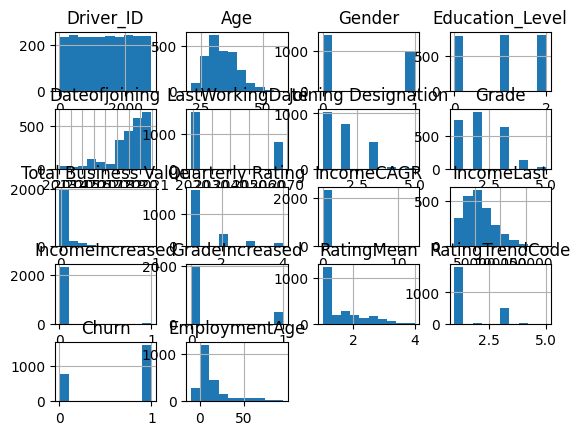

```python
#Lets first quickly plot all variables' histograms
drivers.hist()
```

### Helper functions

#### drawDetailedBoxPlot

Creating a helper function to plot a boxplot that shows detailed quartile information

```python
def drawDetailedBoxPlot(data,ax):
    boxplot = ax.boxplot(data, vert=False, patch_artist=True)

    # Calculate the five-number summary
    min_val = np.min(data)
    q1 = np.percentile(data, 25)
    median = np.median(data)
    q3 = np.percentile(data, 75)
    max_val = np.max(data)

    iqr = q3-q1
    # Calculate outlier boundaries
    lower_bound = q1 - 1.5 * iqr
    upper_bound = q3 + 1.5 * iqr


    arrowprops0 = dict(facecolor='black', shrink=0.05,mutation_scale=10)
    arrowprops1=dict(
                        arrowstyle='->',
                        color='black',
                        lw=1.8,           # Line width
                        mutation_scale=20 # Head size
                    )

    # Annotate the five-number summary on the boxplot


    ax.annotate(f'Min', xy=(min_val, 1), xytext=(min_val, 1.2),
                arrowprops=arrowprops1 , ha='center'  )

    ax.annotate(f'{min_val:.2f}', xy=(min_val, 1), xytext=(min_val, 0.87),ha='center')


    ax.annotate(f'Q1', xy=(q1, 1.07), xytext=(q1, 1.25),
                arrowprops=arrowprops1 , ha='center'  )
    ax.annotate(f'{q1:.2f}', xy=(q1, 1), xytext=(q1, 0.87),ha='center')


    ax.annotate(f'Median', xy=(median, 1.07), xytext=(median, 1.32),
                arrowprops=arrowprops1,ha='center'  )
    ax.annotate(f'{median:.2f}', xy=(median, 1), xytext=(median, 0.77),ha='center')

    ax.annotate(f'Q3', xy=(q3, 1.07), xytext=(q3, 1.25),
                arrowprops=arrowprops1 , ha='center')
    ax.annotate(f'{q3:.2f}', xy=(q3, 1), xytext=(q3, 0.87),ha='center')

    ax.annotate(f'Max', xy=(max_val, 1), xytext=(max_val, 1.2),
                arrowprops=arrowprops1 , ha='center')
    ax.annotate(f'{max_val:.2f}', xy=(max_val, 1), xytext=(max_val, 0.87),ha='center')

    # Add vertical dotted lines for outlier boundaries
    ax.axvline(lower_bound, color='red', linestyle='--', alpha=0.7, label=f'Lower Bound ({lower_bound:.1f})')
    ax.axvline(upper_bound, color='red', linestyle='--', alpha=0.7, label=f'Upper Bound ({upper_bound:.1f})')
    # Add vertical text labels along the lines
    ax.text(lower_bound, .7, 'Lower Bound', rotation=90, ha='center', va='bottom', color='black', fontsize=10)
    ax.text(upper_bound, .7, 'Upper Bound', rotation=90, ha='center', va='bottom', color='black', fontsize=10)
    return ax
```

#### annotate_bars

Helper function to add values on top of bars.

```python
#Helper function to add values on top of bars.
def annotate_bars(barplot,fmt='%.1f'):
    # --- Annotate the bars ---
    for container in barplot.containers:
        barplot.bar_label(
            container,
            fmt=fmt,       # Format as 1 decimal + %
            label_type='edge',  # Label outside bar; use 'center' to put inside
            fontsize=9,
            padding=2
        )
```

#### univariate_ordinal_analysis

Creating a helper function to plot multiple graphs in one figure for ordinal data

```python
import pandas as pd
import matplotlib.pyplot as plt

def univariate_ordinal_analysis(series, column_name, order=None ):
    """
    Print summary statistics and plot distribution for an ordinal categorical Series.

    Parameters:
        series : pd.Series
            The ordinal categorical column.
        order : list (optional)
            Ordered list of categories (if not the Series' CategoricalDtype).
    """

    # Ensure categorical with order
    if not pd.api.types.is_categorical_dtype(series):
        series = series.astype("category")
    if order is not None:
        series = series.cat.set_categories(order, ordered=True)

    # Value counts in order
    counts = series.value_counts().reindex(series.cat.categories)
    perc = counts / counts.sum() * 100



    # Plot
    fig, ax = plt.subplots(1, 2, figsize=(10, 4))

    # Bar plot (counts)
    bars = counts.plot(kind="bar", ax=ax[0], color="skyblue")
    ax[0].set_title(f"{column_name} Counts by Category")
    ax[0].set_ylabel("Count")

    # --- Annotate each bar with count and percentage ---
    total = sum(p.get_height() for p in ax[0].patches)
    for patch in ax[0].patches:
        height = patch.get_height()
        if height > 0:
            pct = height / total * 100
            ax[0].text(
                patch.get_x() + patch.get_width() / 2,  # center of bar
                height + (total * 0.005),               # position slightly above bar
                f"{int(height)}\n({pct:.1f}%)",         # count + % in next line
                ha='center', va='bottom', fontsize=8, color='black'
            )

    # Cumulative percentage
    perc.cumsum().plot(marker="o", ax=ax[1], color="red")
    ax[1].set_title("Cumulative % by Category")
    ax[1].set_ylabel("Cumulative %")
    ax[1].set_ylim(0, 100)
    ax[1].grid(True, linestyle="--", alpha=0.5)

    plt.tight_layout()
    plt.show()
        # Print summary
    print(f"\n📊 Summary Statistics for {column_name}")
    print("="*50)
    print(f"Mode   : {series.mode().iloc[0]}")
    print(f"Median : {series.sort_values().iloc[len(series)//2]}")
    # print("\nValue Counts (%):")
    # df_analysis=pd.DataFrame({"Count": counts, "Percent": perc.round(2)})
    # print(df_analysis)
    # df_analysis.sort_values(by="Percent", ascending=False, inplace=True)
    # print("Breakup of grades-"+", ".join([f"{idx} ({row['Percent']}%)" for idx, row in df_analysis.iterrows()]))
```

#### univariate_numerical_analysis

Creating a helper function to plot multiple graphs and other interesting information for a numerical column

```python
import scipy.stats as stats
import matplotlib.gridspec as gridspec
def univariate_numerical_analysis(data, column_name="Numerical Variable", binsAndLabels=None):
    """
    Perform detailed univariate analysis for a numerical variable, combining descriptive
    statistics, normality testing, and visual insights into a single 4-panel plot.
    It also gives option where we can bin the data.
    Binning adds an extra layer of insight — it transforms raw, continuous data into meaningful
    segments that reveal patterns we might otherwise miss (like which age group dominates or where
    behavior shifts occur).
    Generate 4 key graphs for univariate analysis of numerical data

    Parameters
    ----------
    data : array-like or pandas Series
        Numerical data to analyze.
    column_name : str, optional
        Name of the variable (used for titles and axis labels). Default is "Numerical Variable".
    binsAndLabels : dict, optional
        Dictionary defining custom bins and labels for grouped frequency visualization.
        Example: {"bins": [0, 30, 40, 50, float('inf')], "labels": ["<30", "30-40", "40-50", "50+"]}
        If None, a histogram with KDE is plotted.


    Example usage:
        bins = [float('-inf'),     30,             40,      50,       float('inf')]
        labels = [          'Young(20-30)', 'Established(30-40)', 'Mature(40-50)','Senior(50+)']
        univariate_numerical_analysis(drivers[col], f"{col} Data", {"bins":bins, "labels":labels})

    Description
    -----------
    Generates a 2x3 grid figure with the following components:
      1. **Distribution Plot** — Histogram with KDE (or bar chart if bins provided).
      2. **Q–Q Plot** — Tests normality visually.
      3. **Box Plot** — Displays spread, quartiles, and outliers.
      4. **Summary Panel** — Lists computed statistics and normality results.

    Computed Statistics
    -------------------
    - Mean, Standard Deviation
    - Min, Max, Quartiles (Q1, Median, Q3), IQR
    - Outlier boundaries and counts (Tukey’s 1.5×IQR rule)
    - Skewness, Kurtosis
    - Shapiro–Wilk test statistic and p-value (sampled if n > 300)

    Notes
    -----
    - Automatically adjusts x-axis label rotation for long category names.
    - Prints key insights to console (e.g., central range, outlier summary).
    """
    #Calculations
    mean = np.mean(data)
    q1= np.percentile(data,25)
    q2= np.percentile(data,50)
    q3= np.percentile(data,75)
    iqr = q3-q1
    # Calculate outlier boundaries
    lower_bound = q1 - 1.5 * iqr
    upper_bound = q3 + 1.5 * iqr
    #Normality test
    #For the Shapiro–Wilk normality test, the recommended maximum sample size is 5,000,
    # but the results become unreliable or overly sensitive beyond roughly 300–500 samples.
    if(len(data)>300):
        test_stat, p_value = stats.shapiro(data.sample(300))

    else:
        test_stat, p_value = stats.shapiro(data)

    # Create subplots
    fig = plt.figure(figsize=(10, 6))
    gs = gridspec.GridSpec(2, 3, figure=fig)
    fig.suptitle(f'Univariate Analysis: {column_name}', fontsize=16, fontweight='bold')

    if(binsAndLabels is None):
    # 1. Histogram with KDE
        ax1 = fig.add_subplot(gs[0, 0:2])
        ax1.hist(data, bins=30, alpha=0.7, color='skyblue', edgecolor='black', density=True)
        # Add KDE curve
        x = np.linspace(data.min(), data.max(), 100)
        kde = stats.gaussian_kde(data)
        ax1.plot(x, kde(x), 'r-', linewidth=2, label='KDE')
        ax1.set_title('Distribution (Histogram + KDE)')
        ax1.set_xlabel(column_name)
        ax1.set_ylabel('Density')
        ax1.legend()
        ax1.grid(True, alpha=0.3)
    else:
        bins = binsAndLabels['bins']
        labels = binsAndLabels['labels']
        df_analysis = pd.cut(data, bins=bins, labels=labels)
        ax1 = fig.add_subplot(gs[0, 0:2])
        df_analysis.value_counts().sort_index().plot.bar(ax1)

        # --- Annotate each bar with count and percentage ---
        total = sum(p.get_height() for p in ax1.patches)
        for patch in ax1.patches:
            height = patch.get_height()
            if height > 0:
                pct = height / total * 100
                ax1.text(
                    patch.get_x() + patch.get_width() / 2,  # center of bar
                    height + (total * 0.005),               # position slightly above bar
                    f"{int(height)}\n({pct:.1f}%)",         # count + % in next line
                    ha='center', va='bottom', fontsize=8, color='black'
                )

        ax1.set_title('Distribution using custom Bins')
        ax1.set_xlabel(column_name)
        labelTextLength = np.array([len(label) for label in labels]).sum()
        if(labelTextLength/len(labels)>10):
            degreeOfXtickRotation = 45
            ha='right'
        else:
            degreeOfXtickRotation = 0
            ha='center'
        plt.setp(ax1.get_xticklabels(), rotation=degreeOfXtickRotation, ha=ha)
        # ax1.tick_params(axis='x', labelrotation=degreeOfXtickRotation, ha=ha)   # we have space to make xticks horizontal
        ax1.set_ylabel('Count')
        ax1.legend()
        ax1.grid(True, alpha=0.3)



    # Q-Q Plot (Normality Check)
    ax2 = fig.add_subplot(gs[0, 2])
    stats.probplot(data, dist="norm", plot=ax2)
    ax2.set_title('Q-Q Plot (Normality Test)')
    ax2.grid(True, alpha=0.3)

    # Box Plot
    ax3 = fig.add_subplot(gs[1, 0:2])
    drawDetailedBoxPlot(data,ax3)

	# Clear the right subplot and add formatted text
    ax4 = fig.add_subplot(gs[1, 2])
    ax4.clear()
    ax4.set_xlim(0, 1)
    ax4.set_ylim(0, 1)
    ax4.axis('off')

    # Add title
    ax4.annotate('Summary Statistics', xy=(0.5, 0.95),
                    ha='center', va='top', fontsize=12, fontweight='bold')

    #Find outliers
    lower_outliers =[]
    upper_outliers=[]
    for x in data:
        if x < lower_bound:
            lower_outliers.append(x)
        elif x > upper_bound:
            upper_outliers.append(x)
    outliers = lower_outliers + upper_outliers
    # Add statistics in a formatted way
    statistics = [
        ('Mean:', f"{mean:.2f}"),
        ('Std Dev:',f"{np.std(data):.2f}" ),
        ('Min Max:',f"({np.min(data):.2f}, {np.max(data):.2f})" ),
        ('25, 50, 75 Percentile:', f"{q1}, {q2:.2f}, {q3}" ),
        ('IQR:', iqr ),
        ('Outliers boundary:', f"({lower_bound},{upper_bound})" ),
        ('Outliers count:', f"{len(outliers)} out of {len(data)} ({np.round(len(outliers)*100/len(data),1)})%" ),
        ('Skewness:', f"{stats.skew(data):.2f}"),
        ('Kurtosis:', f"{stats.kurtosis(data):.2f}"),
    ]

    if p_value<0.05:
        statistics.append(("Distribution",f"NOT Normal. Shapiro pval {p_value:.3f}"))
    else:
        statistics.append(("Distribution",f"normal Shapiro pval {p_value}"))

    print(f"Mean value is {mean:.2f} with 50% of data lying between {q1} and {q3}")
    if(len(outliers)>0):
        print(f"There are {len(outliers)} outliers. {len(lower_outliers)} outliers are on lower side and {len(upper_outliers)} outliers are on upper side\n")

    y_pos = 0.85
    for label, value in statistics:
        ax4.annotate(f'{label:.<20} {value}', xy=(0.1, y_pos),
                    ha='left', va='top', fontfamily='monospace', fontsize=8)
        y_pos -= 0.08

    plt.tight_layout()
    plt.show()
```

#### make_normal

- If data is not normal, we can use this function.
- It automatically detects whether the numerical data can use Box–Cox or needs Yeo–Johnson, applies it, and optionally plots before–after comparisons and returns the transformed data.

```python
import numpy as np
import matplotlib.pyplot as plt
from scipy import stats
from sklearn.preprocessing import PowerTransformer

def make_normal(data, column_name="Numerical Variable", plot=True):
    """
    Apply a power transformation (Box–Cox or Yeo–Johnson) to make a numerical column
    approximately normal.

    Parameters
    ----------
    data : array-like or pandas Series
        Numerical data to transform.
    column_name : str, optional
        Name of the variable (used in plots).
    plot : bool, optional
        If True, shows before–after histograms and Q–Q plots.

    Returns
    -------
    transformed_data : numpy.ndarray
        The transformed data as a NumPy array (mean≈0, std≈1).
    transformer : sklearn.preprocessing.PowerTransformer
        The fitted transformer object (can be reused for inverse_transform).

    Notes
    -----
    - Automatically chooses:
        • Box–Cox if all values > 0
        • Yeo–Johnson if data includes zero or negative values
    - Uses Shapiro–Wilk test (n≤300) to assess normality after transformation.
    """

    data = np.asarray(data).reshape(-1, 1)

    # Choose transformation method
    if (data <= 0).any():
        method = 'yeo-johnson'
        print(f"Detected zero/negative values → using Yeo–Johnson transformation for '{column_name}'")
    else:
        method = 'box-cox'
        print(f"All values positive → using Box–Cox transformation for '{column_name}'")

    # Apply transformation
    pt = PowerTransformer(method=method, standardize=True)
    transformed = pt.fit_transform(data).flatten()

    # Shapiro–Wilk test for normality
    sample = transformed if len(transformed) <= 300 else np.random.choice(transformed, 300, replace=False)
    stat, p_value = stats.shapiro(sample)
    print(f"Shapiro–Wilk p-value after transformation: {p_value:.4f}")
    if p_value > 0.05:
        print("✅ Distribution is approximately normal.")
    else:
        print("⚠️ Distribution still deviates slightly from normality.")

    # Optional visualization
    if plot:
        fig, axes = plt.subplots(2, 2, figsize=(10, 6))
        fig.suptitle(f"Normality Transformation: {column_name}", fontsize=14, fontweight='bold')

        # Histogram before
        axes[0, 0].hist(data, bins=30, color='skyblue', edgecolor='black', density=True)
        axes[0, 0].set_title("Original Distribution")

        # Histogram after
        axes[0, 1].hist(transformed, bins=30, color='lightgreen', edgecolor='black', density=True)
        axes[0, 1].set_title("Transformed Distribution")

        # Q-Q before
        stats.probplot(data.flatten(), dist="norm", plot=axes[1, 0])
        axes[1, 0].set_title("Q–Q Plot (Before)")

        # Q-Q after
        stats.probplot(transformed, dist="norm", plot=axes[1, 1])
        axes[1, 1].set_title("Q–Q Plot (After)")

        plt.tight_layout()
        plt.show()

    return transformed, pt
```

```python
drivers.columns
```

```
Index(['Driver_ID', 'Age', 'Gender', 'City', 'Education_Level',
       'Dateofjoining', 'LastWorkingDate', 'Joining Designation', 'Grade',
       'Total Business Value', 'Quarterly Rating', 'IncomeCAGR', 'IncomeLast',
       'IncomeIncreased', 'GradeIncreased', 'RatingMean', 'RatingTrend',
       'RatingTrendCode', 'Ratings', 'Churn', 'EmploymentAge'],
      dtype='object')
```

### Driver_ID

```python
col = 'Driver_ID'

len(drivers[col])
```

```
2381
```

We have 2381 drivers' data

### Age

We try to bin the drivers in following categories

| Bin | Age Range | Label | Description |
| --- | --- | --- | --- |
| 1 | 20–29 | Young entrants | Early career, energetic but less experienced |
| 2 | 30–39 | Established | Peak stamina and experience |
| 3 | 40–49 | Mature | Reliable, possibly long-time drivers |
| 4 | 50–60 | Senior | Experience-rich, may prefer shorter shifts |

```
Mean value is 33.66 with 50% of data lying between 29.0 and 37.0
There are 25 outliers. 0 outliers are on lower side and 25 outliers are on upper side
```

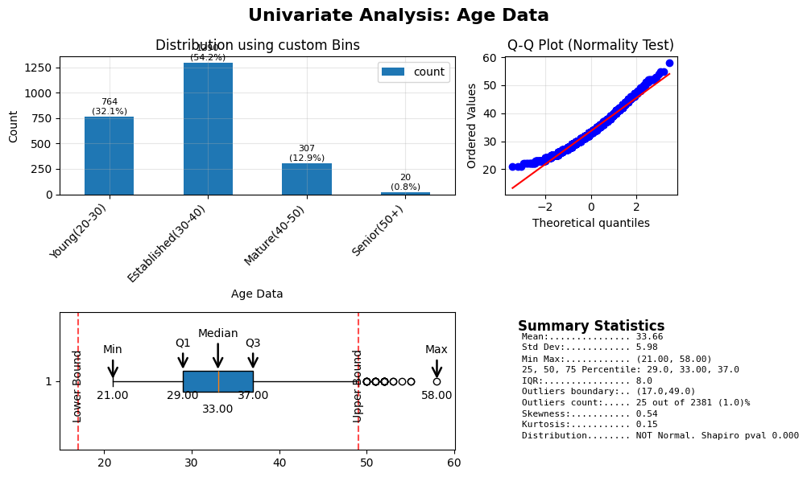

```python
col = 'Age'

bins = [float('-inf'),     30,             40,      50,       float('inf')]
labels = [          'Young(20-30)', 'Established(30-40)', 'Mature(40-50)','Senior(50+)']

univariate_numerical_analysis(drivers[col], f"{col} Data", {"bins":bins, "labels":labels})
```

50% of drivers are between age of 29 and 37. Mean age is 33

32% drivers are between age 20-30, usually energetic but less experienced

54% drivers are between age 30-40, can be considered to have peak stamina and experience

Youngest driver is 21 yrs and oldest is 58 yrs of age

```
All values positive → using Box–Cox transformation for 'Age Data'
Shapiro–Wilk p-value after transformation: 0.2133
✅ Distribution is approximately normal.
```

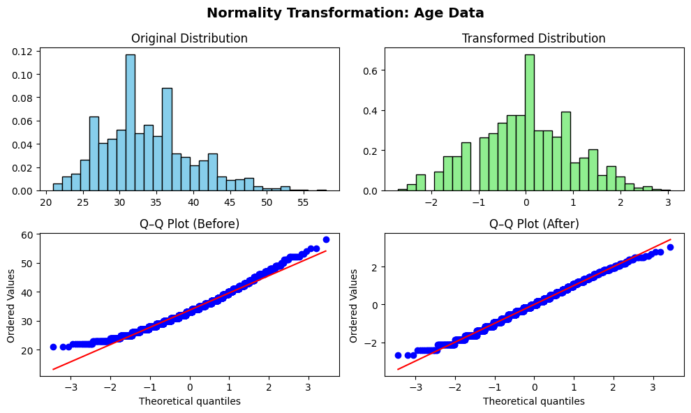

```
(array([-0.96064613, -0.36789145,  1.4650352 , ...,  1.71117629,
        -0.96064613, -0.55765357], shape=(2381,)),
 PowerTransformer(method='box-cox'))
```

```python
make_normal(drivers[col],f"{col} Data")
```

### Gender

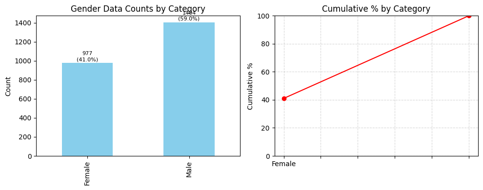

```
📊 Summary Statistics for Gender Data
==================================================
Mode   : Male
Median : Male
```

```python
col = 'Gender'

univariate_ordinal_analysis(driversWithCategories[col], f"{col} Data")
```

59% of drivers are males and 41% are females. That is an awesome ratio

### Education_Level

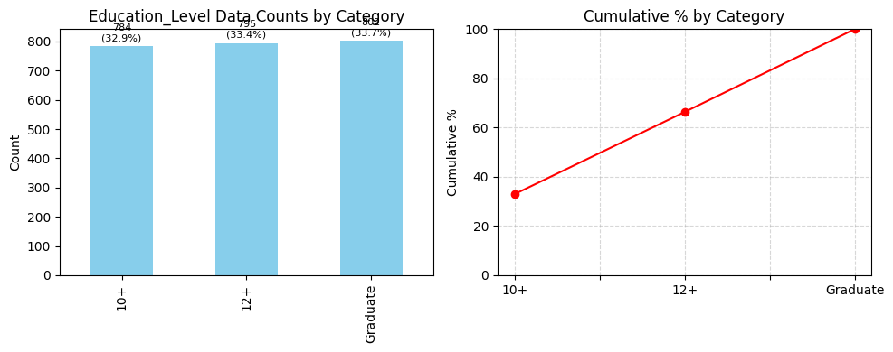

```
📊 Summary Statistics for Education_Level Data
==================================================
Mode   : Graduate
Median : 12+
```

```python
col = 'Education_Level'

univariate_ordinal_analysis(driversWithCategories[col], f"{col} Data")
```

The education level stats are evenly distributed across 10+ , 12+ and graduates. Each category is roughly 33%

### Dateofjoining

Lets make a separate dataframe and then add year and month columns for further analysis

```python
df_doj = drivers[['Dateofjoining']].copy()
df_doj['year'] = df_doj.Dateofjoining.dt.year
df_doj['month'] = df_doj.Dateofjoining.dt.month
# Create a 'year_month' column using dt.to_period('M') for 'Month'
df_doj['year_month'] = df_doj['Dateofjoining'].dt.to_period('M')
df_doj
```

|  | Dateofjoining | year | month | year_month |
| --- | --- | --- | --- | --- |
| 0 | 2018-12-24 | 2018 | 12 | 2018-12 |
| 1 | 2020-06-11 | 2020 | 6 | 2020-06 |
| 2 | 2019-07-12 | 2019 | 7 | 2019-07 |
| 3 | 2019-09-01 | 2019 | 9 | 2019-09 |
| 4 | 2020-07-31 | 2020 | 7 | 2020-07 |
| ... | ... | ... | ... | ... |
| 2376 | 2015-10-15 | 2015 | 10 | 2015-10 |
| 2377 | 2020-08-28 | 2020 | 8 | 2020-08 |
| 2378 | 2018-07-31 | 2018 | 7 | 2018-07 |
| 2379 | 2018-07-21 | 2018 | 7 | 2018-07 |
| 2380 | 2020-08-06 | 2020 | 8 | 2020-08 |

2381 rows × 4 columns

#### Overall Trend Analysis (Yearly Growth/Decline)

- How is the overall number of new joiners changing year after year?

```
[]
```

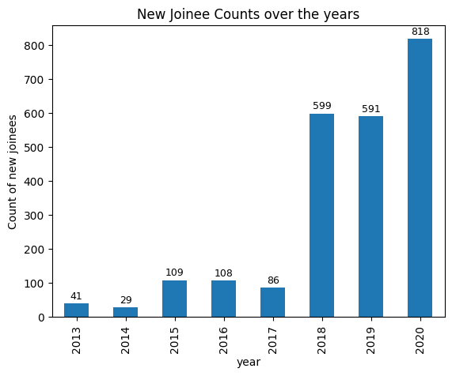

```python
bars = df_doj.year.value_counts().sort_index().plot.bar()
annotate_bars(bars,'%.0f')
plt.ylabel("Count of new joinees")
plt.title("New Joinee Counts over the years")
plt.plot()
```

#### Overall Trend Analysis (Monthly Growth/Decline)

I want to see the trend on monthly basis over the years.

```python
# Group by this column and get the count of joiners for each month
monthly_counts_series_joinees = df_doj.groupby('year_month').size()
```

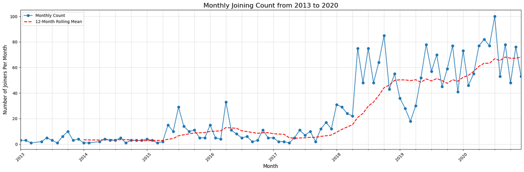

```python
plt.figure(figsize=(18, 6)) # A wider figure is needed for a long time axis

# Directly plot the series
# Pandas is smart enough to plot the PeriodIndex correctly
# Plot the monthly data
monthly_counts_series_joinees.plot(kind='line', marker='o', linestyle='-', label='Monthly Count')

# Compute and plot the n-month rolling mean
window=12
rolling_mean = monthly_counts_series_joinees.rolling(window=window).mean()
rolling_mean.plot(color='red', linewidth=2, linestyle='--', label=f'{window}-Month Rolling Mean')


# Add informative titles and labels
plt.title('Monthly Joining Count from 2013 to 2020', fontsize=16)
plt.xlabel('Month', fontsize=12)
plt.ylabel('Number of Joiners Per Month', fontsize=12)
plt.grid(True, which='both', linestyle='--', linewidth=0.5)

# Improve readability of x-axis labels
plt.xticks(rotation=45) # Rotate labels to prevent overlap
plt.tight_layout() # Adjust plot to ensure everything fits without overlapping
plt.legend()
# Display the plot
plt.show()
```

```python
df_doj.year.value_counts().mean()
```

```
np.float64(297.625)
```

On yearly basis, it is still more than pre-2018 levels though.

📊 Observation from the 12-month rolling mean (red dashed line) and the raw monthly counts (blue line):

- 2013–2017:
  - Very low and irregular joining numbers.
  - Rolling mean is flat to slightly declining → stable but modest hiring.

Late 2017–2018:

- A sharp inflection upward in both monthly counts and rolling mean.
- Indicates a period of rapid growth or expansion.

2019–2020:

- Despite some fluctuations, the rolling mean continues to rise, reaching its highest level by late 2020.
- This suggests sustained and accelerating hiring activity.

2020-Onwards

- During the pandemic (2020 onward), many people lost traditional employment or faced income uncertainty.
- The gig platforms absorbed part of that displaced workforce, leading to a visible rise in joiners even when the broader economy was weak.
- This aligns with global data showing spikes in gig work registrations during and right after lockdown periods.

Overall summary

Hiring in the mobility platform sector accelerated sharply after 2018 and remained high through 2020, indicating strong supply-side participation as workers sought flexible earning avenues amid pandemic-era job disruptions.

#### Seasonality Analysis (Which months are busiest overall?)

- We want to find out which months are consistently the busiest, regardless of the year.

```
[]
```

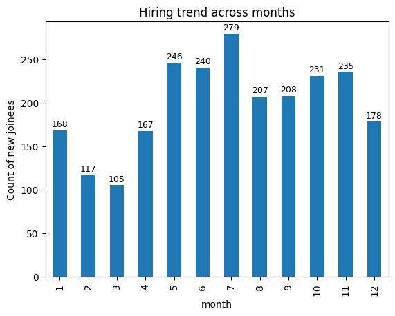

```python
bars=df_doj.month.value_counts().sort_index().plot.bar()
annotate_bars(bars,'%.0f')
plt.title("Hiring trend across months")
plt.ylabel("Count of new joinees")
plt.plot()
```

July, June and May are the most prolific hiring months.

March is lowest in terms of number of hirings

**Lets see how the hiring varied across months over the years.**

- We use line plot, as it is well-suited for displaying trends and comparing them across different years within the Dateofjoining column.

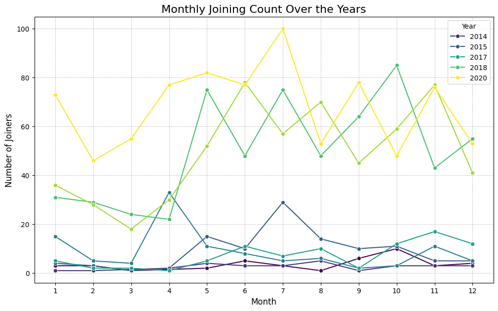

```python
monthly_counts = df_doj.groupby(['year', 'month']).size().reset_index(name='count')
# Set the size of the plot
plt.figure(figsize=(12, 7))

# Create the line plot using Seaborn
# x='month': Months on the x-axis
# y='count': The number of people joining on the y-axis
# hue='year': Create a separate colored line for each unique year
sns.lineplot(data=monthly_counts, x='month', y='count', hue='year', marker='o', palette='viridis')

# Add informative titles and labels
plt.title('Monthly Joining Count Over the Years', fontsize=16)
plt.xlabel('Month', fontsize=12)
plt.ylabel('Number of Joiners', fontsize=12)
plt.xticks(range(1, 13)) # Ensure all 12 months are shown as ticks on the x-axis
plt.grid(True, which='both', linestyle='--', linewidth=0.5)
plt.legend(title='Year')

# Display the plot
plt.show()
```

A heatmap is a fantastic way to visualize the same data

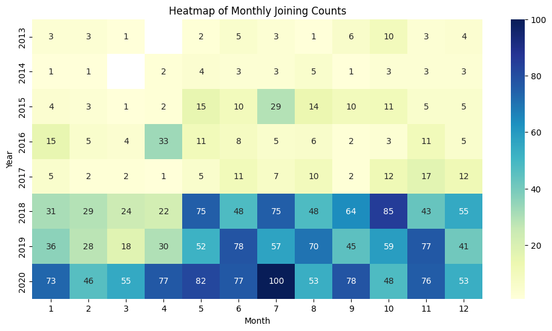

```python
# Pivot the monthly_counts table to get years as rows and months as columns
heatmap_data = monthly_counts.pivot(index='year', columns='month', values='count')

plt.figure(figsize=(12, 6))
sns.heatmap(heatmap_data, annot=True, fmt='g', cmap='YlGnBu') # fmt='g' prevents scientific notation
plt.title('Heatmap of Monthly Joining Counts')
plt.xlabel('Month')
plt.ylabel('Year')
plt.show()
```

```python
df_doj.year.value_counts()
```

```
year
2020    818
2018    599
2019    591
2015    109
2016    108
2017     86
2013     41
2014     29
Name: count, dtype: int64
```

This confirms the trend that last three years have been higher in terms of hiring

July 2020, the time just after pandemic, when most people were at home, ordering stuff and getting it delivered at doorstep saw the highest hiring for gig workers.

### LastWorkingDate

```python
drivers[['LastWorkingDate','Churn']]
```

|  | LastWorkingDate | Churn |
| --- | --- | --- |
| 0 | 2019-11-03 | 1 |
| 1 | 2067-12-31 | 0 |
| 2 | 2020-04-27 | 1 |
| 3 | 2019-07-03 | 1 |
| 4 | 2067-12-31 | 0 |
| ... | ... | ... |
| 2376 | 2067-12-31 | 0 |
| 2377 | 2020-10-28 | 1 |
| 2378 | 2019-09-22 | 1 |
| 2379 | 2019-06-20 | 1 |
| 2380 | 2067-12-31 | 0 |

2381 rows × 2 columns

- Since we filled the last working day value for current drivers with dummy value, we can filter those rows using the churn field
- Lets create a dataframe df_lwd with only those drivers that left (churned).

```python
df_lwd = drivers[drivers.Churn==1].LastWorkingDate.to_frame().reset_index()
df_lwd['year'] = df_lwd.LastWorkingDate.dt.year
df_lwd['month'] = df_lwd.LastWorkingDate.dt.month
df_lwd['year_month'] = df_lwd['LastWorkingDate'].dt.to_period('M')
df_lwd
```

|  | index | LastWorkingDate | year | month | year_month |
| --- | --- | --- | --- | --- | --- |
| 0 | 0 | 2019-11-03 | 2019 | 11 | 2019-11 |
| 1 | 2 | 2020-04-27 | 2020 | 4 | 2020-04 |
| 2 | 3 | 2019-07-03 | 2019 | 7 | 2019-07 |
| 3 | 5 | 2020-11-15 | 2020 | 11 | 2020-11 |
| 4 | 7 | 2019-12-21 | 2019 | 12 | 2019-12 |
| ... | ... | ... | ... | ... | ... |
| 1611 | 2373 | 2020-02-14 | 2020 | 2 | 2020-02 |
| 1612 | 2375 | 2019-08-16 | 2019 | 8 | 2019-08 |
| 1613 | 2377 | 2020-10-28 | 2020 | 10 | 2020-10 |
| 1614 | 2378 | 2019-09-22 | 2019 | 9 | 2019-09 |
| 1615 | 2379 | 2019-06-20 | 2019 | 6 | 2019-06 |

1616 rows × 5 columns

I want to see the trend on monthly basis over the years.

```
[]
```

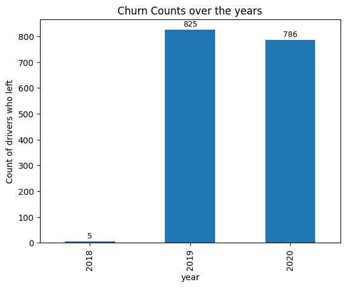

```python
bars=df_lwd.year.value_counts().sort_index().plot.bar()
annotate_bars(bars,'%.0f')
plt.ylabel("Count of drivers who left")
plt.title("Churn Counts over the years")
plt.plot()
```

780+ people left the organization in each of the past 2 years (2019 and 2020)

#### Overall Trend Analysis (Monthly Growth/Decline)

I want to see the trend on monthly basis over the years.

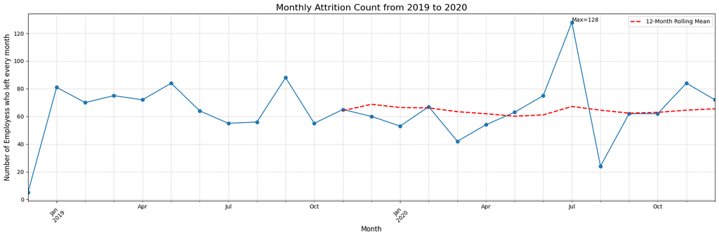

```python
# Group by this column and get the count of joiners for each month
monthly_counts_series_churn = df_lwd.groupby('year_month').size()
plt.figure(figsize=(18, 6)) # A wider figure is needed for a long time axis

# Directly plot the series
# Pandas is smart enough to plot the PeriodIndex correctly
monthly_counts_series_churn.plot(kind='line', marker='o', linestyle='-')

# Compute and plot the n-month rolling mean
window=12
rolling_mean = monthly_counts_series_churn.rolling(window=window).mean()
rolling_mean.plot(color='red', linewidth=2, linestyle='--', label=f'{window}-Month Rolling Mean')


#Print max value
plt.text(x=monthly_counts_series_churn.index[monthly_counts_series_churn.argmax()],
         y=monthly_counts_series_churn.max()+0.5,

         s=f'Max={monthly_counts_series_churn.max()}')

# Add informative titles and labels
plt.title('Monthly Attrition Count from 2019 to 2020', fontsize=16)
plt.xlabel('Month', fontsize=12)
plt.ylabel('Number of Employess who left every month', fontsize=12)
plt.grid(True, which='both', linestyle='--', linewidth=0.5)

# Improve readability of x-axis labels
plt.xticks(rotation=45) # Rotate labels to prevent overlap
plt.tight_layout() # Adjust plot to ensure everything fits without overlapping
plt.legend()
# Display the plot
plt.show()
```

Mean monthly atttrition is 64 drivers, with maximum at 128 in Jul 2020. So this means both the hiring count (100) and churn count (128) was maximum in July 2020

### Joining Designation

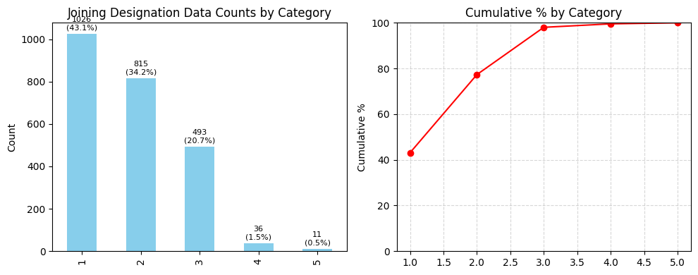

```
📊 Summary Statistics for Joining Designation Data
==================================================
Mode   : 1
Median : 2
```

```python
col = 'Joining Designation'

univariate_ordinal_analysis(drivers[col], f"{col} Data")
```

43.09% drivers joined at Grade 1, 34.23% at Grade 2, 20.71% at Grade 3 and only 1.51% at Grade 4 and 0.46% at Grade 5

### Grade

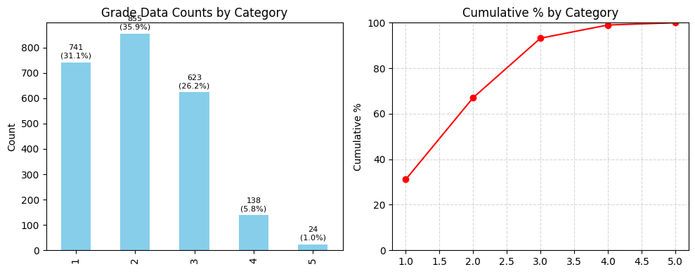

```
📊 Summary Statistics for Grade Data
==================================================
Mode   : 2
Median : 2
```

```python
col = 'Grade'

univariate_ordinal_analysis(drivers[col], f"{col} Data")
```

At present, 31% of drivers are at Grade 1, 36% at Grade 2, 26% at Grade 3, 6% at Grade 4 and 1% at Grade 5

### Total Business Value

```
Mean value is 4586741.82 with 50% of data lying between 0.0 and 4173650.0
There are 336 outliers. 0 outliers are on lower side and 336 outliers are on upper side
```

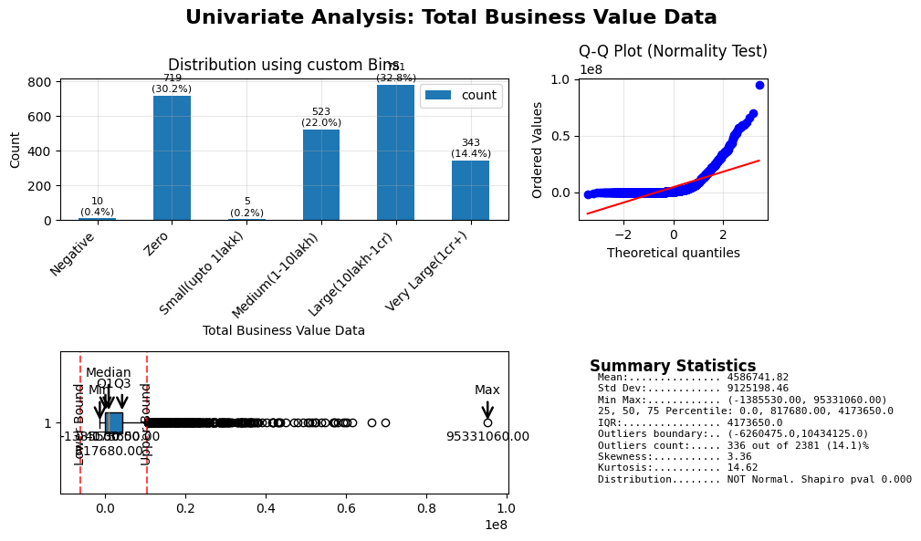

```python
col = 'Total Business Value'

bins = [-np.inf,   -0.1,    0.1,   1_00_000,       10_00_000,      1_00_00_000,           np.inf]
labels = ['Negative', 'Zero','Small(upto 1lakk)',   'Medium(1-10lakh)',      'Large(10lakh-1cr)', 'Very Large(1cr+)']
univariate_numerical_analysis(drivers[col], f"{col} Data", {"bins":bins, "labels":labels})
```

14% of drivers contributed betweeen 1 cr and 10 cr

54% of drivers contributed betweeen 1lakh and 1 cr

30% of drivers contributed zero

0.4% of drivers contributed negative

- We have large range of Total business value, including zero and negative values. We use np.log1p() to handle zeros safely.
- This means each value plotted on the x-axis is logₑ(1 + x), where x = original “Total Business Value”.
- In X axis, actually we have log, but we will try to show actual rupee value for better interpretation

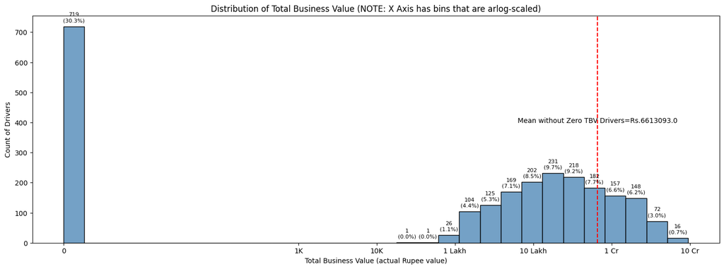

```python
#sns.histplot(np.log1p(drivers['Total Business Value']))


x = drivers['Total Business Value']

# Create log-transformed version (log(1+x))
log_vals = np.log1p(x)
plt.figure(figsize=(18, 6)) # A wider figure is needed for a long time axis
# Plot
ax=sns.histplot(log_vals, bins=30, color='steelblue', edgecolor='black')

# --- Custom tick labels ---
# Define the actual numeric values you want to show on x-axis
tick_values = [0, 1_000, 10_000, 1_00_000, 10_00_000, 1_00_00_000, 10_00_00_000]
# Convert those to their log1p equivalents for positioning
tick_positions = np.log1p(tick_values)
# Apply them
#plt.xticks(tick_positions, [f"{v:,}" for v in tick_values])
plt.xticks(tick_positions, ["0", "1K", "10K", "1 Lakh", "10 Lakh", "1 Cr", "10 Cr"])


# --- Annotate each bar with count and percentage ---
total = sum(p.get_height() for p in ax.patches)
heights=[]
for patch in ax.patches:
    height = patch.get_height()
    heights.append(height)
    if height > 0:
        pct = height / total * 100
        ax.text(
            patch.get_x() + patch.get_width() / 2,  # center of bar
            height + (total * 0.005),               # position slightly above bar
            f"{int(height)}\n({pct:.1f}%)",         # count + % in next line
            ha='center', va='bottom', fontsize=8, color='black'
        )
meanWithoutZeroTBV = x[x>0].mean()
plt.axvline(x=np.log1p(meanWithoutZeroTBV), c='r',linestyle='--')

#Print mean value
plt.text(x=np.log1p(meanWithoutZeroTBV),
         y=400,
         s=f'Mean without Zero TBV Drivers=Rs.{np.floor(meanWithoutZeroTBV)}', ha='center')
# Label axes
plt.xlabel("Total Business Value (actual Rupee value)")
plt.ylabel("Count of Drivers")
plt.title("Distribution of Total Business Value (NOTE: X Axis has bins that are arlog-scaled)")
```

- Log scale makes it easy to observe a very broad range of data.
- Mean TBV value after removing drivers with Zero TBV is Rs 66lakh

#### Categorize drivers based on TBV

```python
count= (drivers['Total Business Value'] > 1_00_00_000).sum()
print(f'Driver count above 1 cr TBV-{ count}, who comprise {count*100/len(drivers)} % ')
count= (drivers['Total Business Value'] > 10_00_000).sum()
print(f'Driver count above 10 lakh TBV-{ count}, who comprise {count*100/len(drivers)} % ')
```

```
Driver count above 1 cr TBV-343, who comprise 14.405711885762285 %
Driver count above 10 lakh TBV-1124, who comprise 47.207055858882825 %
```

#### Analysing positive values

- Let us see max value
- Let us see top values

```python
drivers[drivers[col] == drivers[col].max()]
```

|  | Driver_ID | Age | Gender | City | Education_Level | Dateofjoining | LastWorkingDate | Joining Designation | Grade | Total Business Value | ... | IncomeCAGR | IncomeLast | IncomeIncreased | GradeIncreased | RatingMean | RatingTrend | RatingTrendCode | Ratings | Churn | EmploymentAge |
| --- | --- | --- | --- | --- | --- | --- | --- | --- | --- | --- | --- | --- | --- | --- | --- | --- | --- | --- | --- | --- | --- |
| 2153 | 2522 | 36.0 | 1.0 | C13 | 1 | 2013-01-04 | 2067-12-31 | 2 | 5 | 95331060 | ... | 0.0 | 90057 | 0 | 1 | 2.75 | stable | 3 | [[4, 4, 4, 4, 4, 4, 3, 3, 3, 2, 2, 2, 1, 1, 1,... | 0 | 94.0 |

1 rows × 21 columns

Driver with ID 2522 has a business value of 9,53,31,060 (9 crore 53 lakh)

There are 343 drivers out 2381 (14%) that have added a total business value of 1crore+

Interpretation of 14% - It points to a classic business phenomenon - **The Power-Law Distribution (or Pareto Principle)**

- This is a textbook example of a power-law distribution, often related to the Pareto Principle (the "80/20 rule").
- **What it means:** A small percentage of drivers (the "Superstars" or "Power Drivers") are generating a massively disproportionate amount of the total business value.
- **Why it's critical:** These 14% of drivers are the most valuable asset the company has. Losing even a small number of these drivers would have a much more significant negative impact on revenue than losing a large number of the low-value or zero-value drivers.

```python
df_original[df_original.Driver_ID==2522]
```

|  | MMM-YY | Driver_ID | Age | Gender | City | Education_Level | Income | Dateofjoining | LastWorkingDate | Joining Designation | Grade | Total Business Value | Quarterly Rating |
| --- | --- | --- | --- | --- | --- | --- | --- | --- | --- | --- | --- | --- | --- |
| 17092 | 2019-01-01 | 2522 | 34.0 | 1.0 | C13 | 1 | 90057 | 2013-01-04 | 2067-12-31 | 2 | 5 | 9830180 | 4 |
| 17093 | 2019-02-01 | 2522 | 34.0 | 1.0 | C13 | 1 | 90057 | 2013-01-04 | 2067-12-31 | 2 | 5 | 165730 | 4 |
| 17094 | 2019-03-01 | 2522 | 34.0 | 1.0 | C13 | 1 | 90057 | 2013-01-04 | 2067-12-31 | 2 | 5 | 20596160 | 4 |
| 17095 | 2019-04-01 | 2522 | 34.0 | 1.0 | C13 | 1 | 90057 | 2013-01-04 | 2067-12-31 | 2 | 5 | 13475510 | 4 |
| 17096 | 2019-05-01 | 2522 | 34.0 | 1.0 | C13 | 1 | 90057 | 2013-01-04 | 2067-12-31 | 2 | 5 | 1710980 | 4 |
| 17097 | 2019-06-01 | 2522 | 34.0 | 1.0 | C13 | 1 | 90057 | 2013-01-04 | 2067-12-31 | 2 | 5 | 0 | 4 |
| 17098 | 2019-07-01 | 2522 | 34.0 | 1.0 | C13 | 1 | 90057 | 2013-01-04 | 2067-12-31 | 2 | 5 | 496420 | 3 |
| 17099 | 2019-08-01 | 2522 | 35.0 | 1.0 | C13 | 1 | 90057 | 2013-01-04 | 2067-12-31 | 2 | 5 | 2000000 | 3 |
| 17100 | 2019-09-01 | 2522 | 35.0 | 1.0 | C13 | 1 | 90057 | 2013-01-04 | 2067-12-31 | 2 | 5 | 2317970 | 3 |
| 17101 | 2019-10-01 | 2522 | 35.0 | 1.0 | C13 | 1 | 90057 | 2013-01-04 | 2067-12-31 | 2 | 5 | 2822560 | 2 |
| 17102 | 2019-11-01 | 2522 | 35.0 | 1.0 | C13 | 1 | 90057 | 2013-01-04 | 2067-12-31 | 2 | 5 | 240000 | 2 |
| 17103 | 2019-12-01 | 2522 | 35.0 | 1.0 | C13 | 1 | 90057 | 2013-01-04 | 2067-12-31 | 2 | 5 | 242540 | 2 |
| 17104 | 2020-01-01 | 2522 | 35.0 | 1.0 | C13 | 1 | 90057 | 2013-01-04 | 2067-12-31 | 2 | 5 | 151100 | 1 |
| 17105 | 2020-02-01 | 2522 | 35.0 | 1.0 | C13 | 1 | 90057 | 2013-01-04 | 2067-12-31 | 2 | 5 | 772670 | 1 |
| 17106 | 2020-03-01 | 2522 | 35.0 | 1.0 | C13 | 1 | 90057 | 2013-01-04 | 2067-12-31 | 2 | 5 | 1381500 | 1 |
| 17107 | 2020-04-01 | 2522 | 35.0 | 1.0 | C13 | 1 | 90057 | 2013-01-04 | 2067-12-31 | 2 | 5 | 0 | 2 |
| 17108 | 2020-05-01 | 2522 | 35.0 | 1.0 | C13 | 1 | 90057 | 2013-01-04 | 2067-12-31 | 2 | 5 | 1400000 | 2 |
| 17109 | 2020-06-01 | 2522 | 35.0 | 1.0 | C13 | 1 | 90057 | 2013-01-04 | 2067-12-31 | 2 | 5 | 2193640 | 2 |
| 17110 | 2020-07-01 | 2522 | 35.0 | 1.0 | C13 | 1 | 90057 | 2013-01-04 | 2067-12-31 | 2 | 5 | 502320 | 2 |
| 17111 | 2020-08-01 | 2522 | 36.0 | 1.0 | C13 | 1 | 90057 | 2013-01-04 | 2067-12-31 | 2 | 5 | 431000 | 2 |
| 17112 | 2020-09-01 | 2522 | 36.0 | 1.0 | C13 | 1 | 90057 | 2013-01-04 | 2067-12-31 | 2 | 5 | 2157900 | 2 |
| 17113 | 2020-10-01 | 2522 | 36.0 | 1.0 | C13 | 1 | 90057 | 2013-01-04 | 2067-12-31 | 2 | 5 | 0 | 4 |
| 17114 | 2020-11-01 | 2522 | 36.0 | 1.0 | C13 | 1 | 90057 | 2013-01-04 | 2067-12-31 | 2 | 5 | -1304840 | 4 |
| 17115 | 2020-12-01 | 2522 | 36.0 | 1.0 | C13 | 1 | 90057 | 2013-01-04 | 2067-12-31 | 2 | 5 | 33747720 | 4 |

#### Analyzing Zero Values

```python
zeroTBVDrivers = drivers[drivers[col] == 0]
print (f'{len(zeroTBVDrivers)}/{len(drivers)} = {len(zeroTBVDrivers)/len(drivers)}')
```

```
719/2381 = 0.30197396052078956
```

Lets observe these rows to see if we can find out more about them

```python
zeroTBVDrivers
```

|  | Driver_ID | Age | Gender | City | Education_Level | Dateofjoining | LastWorkingDate | Joining Designation | Grade | Total Business Value | ... | IncomeCAGR | IncomeLast | IncomeIncreased | GradeIncreased | RatingMean | RatingTrend | RatingTrendCode | Ratings | Churn | EmploymentAge |
| --- | --- | --- | --- | --- | --- | --- | --- | --- | --- | --- | --- | --- | --- | --- | --- | --- | --- | --- | --- | --- | --- |
| 1 | 2 | 31.0 | 0.0 | C7 | 2 | 2020-06-11 | 2067-12-31 | 2 | 2 | 0 | ... | 0.0 | 67016 | 0 | 0 | 1.0 | consistent_low | 1 | [[1, 1]] | 0 | 5.0 |
| 5 | 8 | 34.0 | 0.0 | C2 | 0 | 2020-09-19 | 2020-11-15 | 3 | 3 | 0 | ... | 0.0 | 70656 | 0 | 0 | 1.0 | consistent_low | 1 | [[1, 1, 1]] | 1 | 1.0 |
| 6 | 11 | 28.0 | 1.0 | C19 | 2 | 2020-07-12 | 2067-12-31 | 1 | 1 | 0 | ... | 0.0 | 42172 | 0 | 0 | 1.0 | consistent_low | 1 | [[1]] | 0 | 4.0 |
| 9 | 14 | 39.0 | 1.0 | C26 | 0 | 2020-10-16 | 2067-12-31 | 3 | 3 | 0 | ... | 0.0 | 19734 | 0 | 0 | 1.0 | consistent_low | 1 | [[1, 1, 1]] | 0 | 1.0 |
| 12 | 18 | 27.0 | 1.0 | C17 | 1 | 2019-09-01 | 2019-04-30 | 1 | 1 | 0 | ... | 0.0 | 31631 | 0 | 0 | 1.0 | consistent_low | 1 | [[1, 1, 1, 1, 1]] | 1 | -5.0 |
| ... | ... | ... | ... | ... | ... | ... | ... | ... | ... | ... | ... | ... | ... | ... | ... | ... | ... | ... | ... | ... | ... |
| 2371 | 2776 | 27.0 | 1.0 | C27 | 1 | 2019-04-01 | 2019-04-04 | 2 | 2 | 0 | ... | 0.0 | 54397 | 0 | 0 | 1.0 | consistent_low | 1 | [[1, 1, 1, 1]] | 1 | 0.0 |
| 2372 | 2778 | 35.0 | 0.0 | C13 | 2 | 2020-11-29 | 2067-12-31 | 2 | 2 | 0 | ... | 0.0 | 50180 | 0 | 0 | 1.0 | consistent_low | 1 | [[1]] | 0 | 0.0 |
| 2373 | 2779 | 28.0 | 0.0 | C26 | 0 | 2020-01-26 | 2020-02-14 | 3 | 3 | 0 | ... | 0.0 | 95133 | 0 | 0 | 1.0 | consistent_low | 1 | [[1, 1]] | 1 | 0.0 |
| 2375 | 2782 | 26.0 | 0.0 | C19 | 1 | 2019-05-16 | 2019-08-16 | 1 | 1 | 0 | ... | 0.0 | 29582 | 0 | 0 | 1.0 | consistent_low | 1 | [[1, 1, 1, 1]] | 1 | 3.0 |
| 2377 | 2785 | 34.0 | 1.0 | C9 | 0 | 2020-08-28 | 2020-10-28 | 1 | 1 | 0 | ... | 0.0 | 12105 | 0 | 0 | 1.0 | consistent_low | 1 | [[1, 1, 1]] | 1 | 2.0 |

719 rows × 21 columns

Lets see their Gender

```python
zeroTBVDrivers.Gender.value_counts(normalize=True)
```

```
Gender
0.0    0.605007
1.0    0.394993
Name: proportion, dtype: float64
```

60% are men

Lets see their city

```python
zeroTBVDrivers.City.value_counts(normalize=True, sort=True)
```

```
City
C20    0.072323
C27    0.047288
C8     0.045897
C15    0.043115
C5     0.041725
C29    0.041725
C10    0.040334
C17    0.038943
C4     0.036161
C12    0.036161
C21    0.036161
C2     0.034771
C9     0.033380
C3     0.033380
C1     0.031989
C28    0.031989
C25    0.030598
C13    0.030598
C19    0.029207
C24    0.029207
C14    0.029207
C11    0.029207
C16    0.029207
C22    0.027816
C23    0.026426
C6     0.025035
C7     0.023644
C18    0.023644
C26    0.020862
Name: proportion, dtype: float64
```

```python
zeroTBVDrivers.Dateofjoining.dt.year.value_counts()
```

```
Dateofjoining
2020    381
2019    202
2018    124
2017      4
2016      4
2013      3
2015      1
Name: count, dtype: int64
```

```python
zeroTBVDrivers.Dateofjoining.dt.year.value_counts(normalize=True)
```

```
Dateofjoining
2020    0.529903
2019    0.280946
2018    0.172462
2017    0.005563
2016    0.005563
2013    0.004172
2015    0.001391
Name: proportion, dtype: float64
```

52% joined in 2020 (less than 12 months ago), 28% joined in 2019(less than 24 months ago), 18% joined in 2018

```python
zeroTBVDrivers.Churn.value_counts(normalize=True)
```

```
Churn
1    0.767733
0    0.232267
Name: proportion, dtype: float64
```

76% of these drivers have LEFT the organization. That explains to a large extent the zero value.

```python
pd.crosstab(zeroTBVDrivers.Dateofjoining.dt.year,zeroTBVDrivers.Churn)
```

| Churn Dateofjoining | 0 | 1 |
| --- | --- | --- |
| 2013 | 0 | 3 |
| 2015 | 0 | 1 |
| 2016 | 0 | 4 |
| 2017 | 0 | 4 |
| 2018 | 0 | 124 |
| 2019 | 6 | 196 |
| 2020 | 161 | 220 |

- The crosstab data clearly confirms that these drivers have basically left the company, which explain the zero TBV value. There are 161 drivers that have recently joined but may not have started taking active rides.
- Let us analyze these 161 drivers who joined in last year and have zero TBV

```python
zeroTBVDriversLastYear = zeroTBVDrivers[(zeroTBVDrivers.Dateofjoining.dt.year==2020) & (zeroTBVDrivers.Churn==0)]
zeroTBVDriversLastYear
```

|  | Driver_ID | Age | Gender | City | Education_Level | Dateofjoining | LastWorkingDate | Joining Designation | Grade | Total Business Value | ... | IncomeCAGR | IncomeLast | IncomeIncreased | GradeIncreased | RatingMean | RatingTrend | RatingTrendCode | Ratings | Churn | EmploymentAge |
| --- | --- | --- | --- | --- | --- | --- | --- | --- | --- | --- | --- | --- | --- | --- | --- | --- | --- | --- | --- | --- | --- |
| 1 | 2 | 31.0 | 0.0 | C7 | 2 | 2020-06-11 | 2067-12-31 | 2 | 2 | 0 | ... | 0.0 | 67016 | 0 | 0 | 1.0 | consistent_low | 1 | [[1, 1]] | 0 | 5.0 |
| 6 | 11 | 28.0 | 1.0 | C19 | 2 | 2020-07-12 | 2067-12-31 | 1 | 1 | 0 | ... | 0.0 | 42172 | 0 | 0 | 1.0 | consistent_low | 1 | [[1]] | 0 | 4.0 |
| 9 | 14 | 39.0 | 1.0 | C26 | 0 | 2020-10-16 | 2067-12-31 | 3 | 3 | 0 | ... | 0.0 | 19734 | 0 | 0 | 1.0 | consistent_low | 1 | [[1, 1, 1]] | 0 | 1.0 |
| 48 | 62 | 27.0 | 0.0 | C9 | 2 | 2020-11-28 | 2067-12-31 | 1 | 1 | 0 | ... | 0.0 | 62376 | 0 | 0 | 1.0 | consistent_low | 1 | [[1]] | 0 | 0.0 |
| 52 | 66 | 27.0 | 1.0 | C4 | 2 | 2020-01-21 | 2067-12-31 | 3 | 3 | 0 | ... | 0.0 | 104286 | 0 | 0 | 1.0 | consistent_low | 1 | [[1, 1]] | 0 | 10.0 |
| ... | ... | ... | ... | ... | ... | ... | ... | ... | ... | ... | ... | ... | ... | ... | ... | ... | ... | ... | ... | ... | ... |
| 2250 | 2635 | 35.0 | 0.0 | C20 | 0 | 2020-11-17 | 2067-12-31 | 2 | 2 | 0 | ... | 0.0 | 66890 | 0 | 0 | 1.0 | consistent_low | 1 | [[1, 1]] | 0 | 0.0 |
| 2253 | 2640 | 32.0 | 1.0 | C29 | 1 | 2020-09-28 | 2067-12-31 | 2 | 2 | 0 | ... | 0.0 | 80788 | 0 | 0 | 1.0 | consistent_low | 1 | [[1, 1, 1]] | 0 | 2.0 |
| 2365 | 2770 | 32.0 | 0.0 | C26 | 0 | 2020-11-29 | 2067-12-31 | 3 | 3 | 0 | ... | 0.0 | 49295 | 0 | 0 | 1.0 | consistent_low | 1 | [[1]] | 0 | 0.0 |
| 2370 | 2775 | 27.0 | 0.0 | C9 | 0 | 2020-02-10 | 2067-12-31 | 3 | 3 | 0 | ... | 0.0 | 85112 | 0 | 0 | 1.0 | consistent_low | 1 | [[1, 1, 1]] | 0 | 9.0 |
| 2372 | 2778 | 35.0 | 0.0 | C13 | 2 | 2020-11-29 | 2067-12-31 | 2 | 2 | 0 | ... | 0.0 | 50180 | 0 | 0 | 1.0 | consistent_low | 1 | [[1]] | 0 | 0.0 |

161 rows × 21 columns

```python
zeroTBVDriversLastYear.IncomeLast.mean()
```

```
np.float64(58908.27329192546)
```

These 161 drivers have consistently poorest rating of 1, but surprisingly, they have a positive income, averaging Rs 58900 monthly!

Let us see if there are other drivers that are also joined in 2020 but have non zero total business value.

```
657
```

```
[]
```

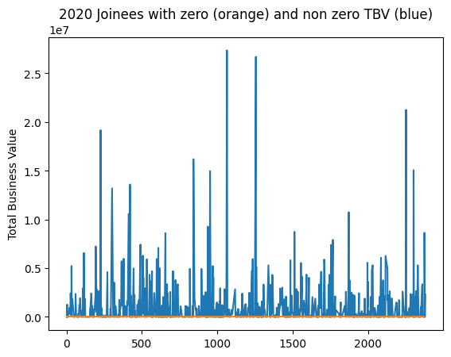

```python
plt.plot(drivers[drivers.Dateofjoining.dt.year==2020]['Total Business Value'])
plt.plot(zeroTBVDriversLastYear['Total Business Value'])
print(len(drivers[drivers.Dateofjoining.dt.year==2020])-len(zeroTBVDriversLastYear))
plt.ylabel("Total Business Value")
plt.title("2020 Joinees with zero (orange) and non zero TBV (blue)")
plt.plot()
```

Indeed, there are a 657 more drivers that too joined in 2020 but have non zero total business value.

Company can investigate if this is a simple case of missing data or what is the reason for zero business value of these 161 recenly joined drivers.

30% (719 of 2381) of drivers have not contributed anything to the total business value (value is zero)

60% of these non contributing drivers are men

City C20 has 7% of these drivers.

52% (381 of 719) joined in 2020 (less than 12 months ago), 28% joined in 2019(less than 24 months ago), 18% joined in 2018

76% (552 of 719) of these drivers have LEFT the organization. That explains to a large extent the zero value.

Out of the remaining 167 drivers that are still with the company, 161 drivers have recently joined (2020) but have zero total business value. We find that these drivers have non zero income, infact their avg income is Rs 58908. So surely they are serving the customers. There were a 657 more drivers that too joined in 2020 but have non zero total business value. Company can investigate if this is a simple case of missing data or what is the reason for zero business value of these 161 recenly joined drivers.

### Quarterly Rating

We are looking at latest values of quarterly ratings for each driver

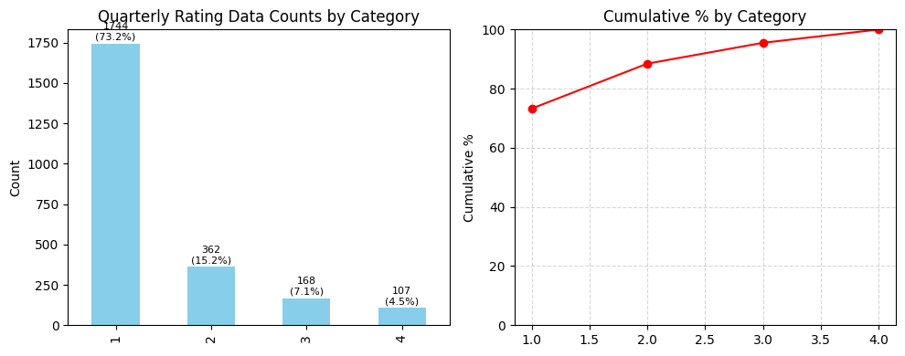

```
📊 Summary Statistics for Quarterly Rating Data
==================================================
Mode   : 1
Median : 1
```

```python
col = 'Quarterly Rating'

univariate_ordinal_analysis(drivers[col], f"{col} Data")
```

73% of drivers have a rating 1, 15% have rating 2, 7% have rating 3 and only 4.4% have top rating of 4

### RatingMean

Lets bin the ratingmean value as it will help in the analysis.

```python
bins = [float('-inf'), 1, 2, 3, float('inf')]
labels = ['1', '2', '3', '4']

df_analysis = pd.cut(drivers['RatingMean'], bins=bins, labels=labels)
df_analysis.value_counts()
```

```
RatingMean
1    1202
2     623
3     447
4     109
Name: count, dtype: int64
```

```python
df_analysis.value_counts(normalize=True)
```

```
RatingMean
1    0.504830
2    0.261655
3    0.187736
4    0.045779
Name: proportion, dtype: float64
```

```
[]
```

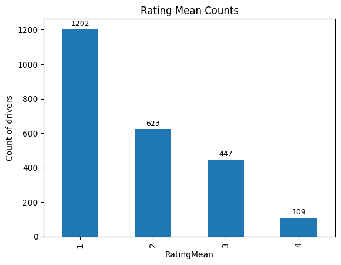

```python
bars=df_analysis.value_counts().plot.bar()
annotate_bars(bars,'%.0f')
plt.title("Rating Mean Counts")
plt.ylabel("Count of drivers")
plt.plot()
```

50% of drivers have rating 1 or less, 26% have mean rating of 1 to 2, 18% have between 2 and 3, and 4.5% have between 3 and 4

### RatingTrend

- We created a RatingTrend column during creation of Drivers dataframe and used logic to assign these values to each driver based on the data of their ratings over the months.
- This is how we can interpret the values in RatingTrend
- 'improving' → if slope > +0.5 (ratings increasing significantly)
- 'degrading' → if slope < -0.5 (ratings decreasing significantly)
- 'consistent_high' → if slope ≈ 0 and mean rating ≥ 4
- 'consistent_low' → if slope ≈ 0 and mean rating ≤ 2
- 'stable' → if slope ≈ 0 and mean rating is mid-range (2–4)

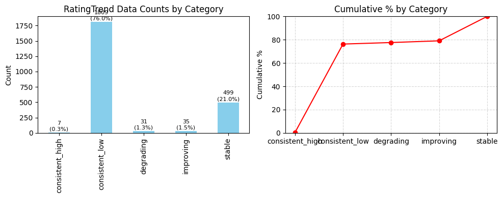

```
📊 Summary Statistics for RatingTrend Data
==================================================
Mode   : consistent_low
Median : consistent_low
```

```python
col = 'RatingTrend'

univariate_ordinal_analysis(drivers[col], f"{col} Data")
```

76% of drivers have consistently low ratings over the months

21% have a rating that has remained around 2-3

Only 1.47% have improved their rating over the months consistently

Only 1.3% have degraded their rating over the months

### IncomeCAGR

```
Mean value is 0.10 with 50% of data lying between 0.0 and 0.0
There are 43 outliers. 0 outliers are on lower side and 43 outliers are on upper side
```

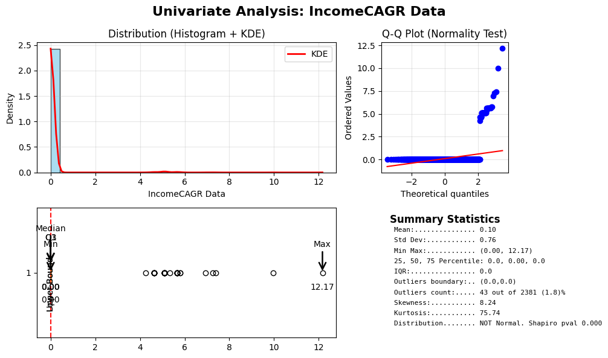

```python
col = 'IncomeCAGR'

univariate_numerical_analysis(drivers[col], f"{col} Data")
```

The data is too skewed,most values are zero. Lets bin the data to see it more clearly

```python
bins = [float('-inf'), 0.1, 5, 10, float('inf')]
labels = ['Zero', '0-5', '5-10', '10+']

df_analysis = pd.cut(drivers['IncomeCAGR'], bins=bins, labels=labels)
df_analysis.value_counts()
```

```
IncomeCAGR
Zero    2338
5-10      33
0-5        9
10+        1
Name: count, dtype: int64
```

```python
df_analysis.value_counts(normalize=True)
```

```
IncomeCAGR
Zero    0.98194
5-10    0.01386
0-5     0.00378
10+     0.00042
Name: proportion, dtype: float64
```

98% of drivers have not had an increase in income

0.3% (9) drivers had an income increase of 0-5%

1.3% (33) drivers had an income increase of 5-10%

Only 1 driver had an income increase of 10+%

### IncomeLast

```
Mean value is 59334.16 with 50% of data lying between 39104.0 and 75986.0
There are 48 outliers. 0 outliers are on lower side and 48 outliers are on upper side
```

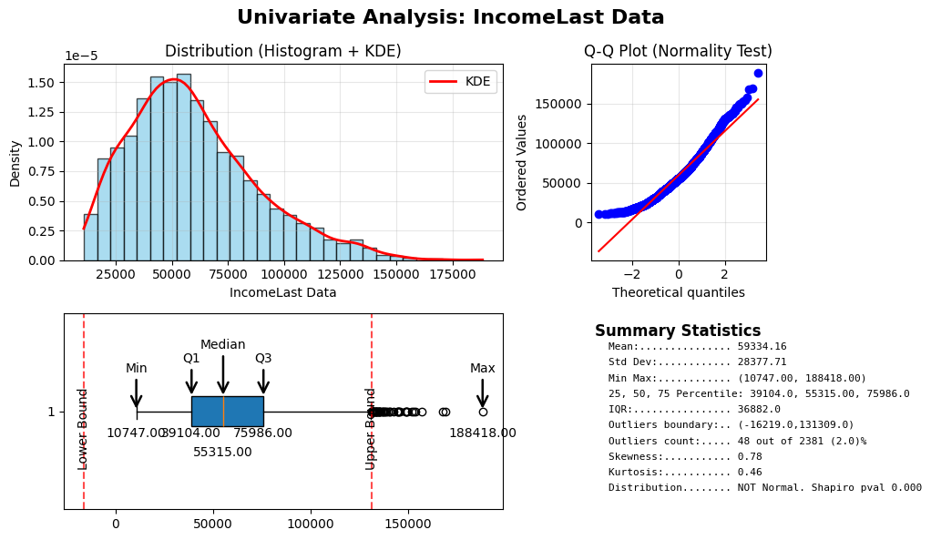

```python
col = 'IncomeLast'

univariate_numerical_analysis(drivers[col], f"{col} Data")
```

Average income per driver is Rs 59334

Maximum income is 1,88,418; Minimum income is 10,747

50% of drivers earn between Rs 39104 to 75986

48 outliers

### IncomeIncreased

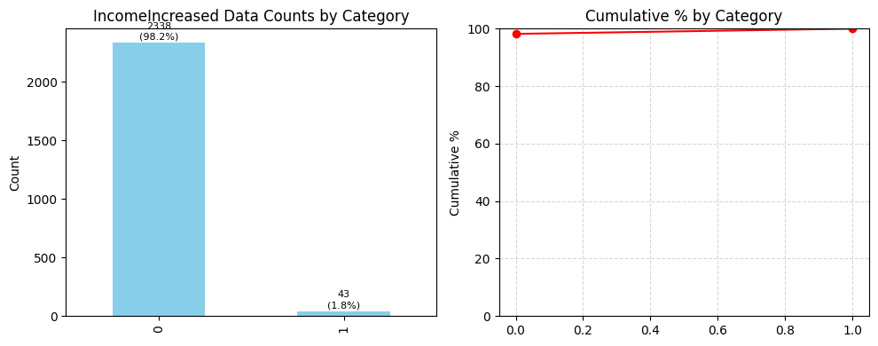

```
📊 Summary Statistics for IncomeIncreased Data
==================================================
Mode   : 0
Median : 0
```

```python
col = 'IncomeIncreased'

univariate_ordinal_analysis(drivers[col], f"{col} Data")
```

This confirms what we found in IncomeCAGR. 98% of drivers have not seen a salary increase in over 2 yrs.

### GradeIncreased

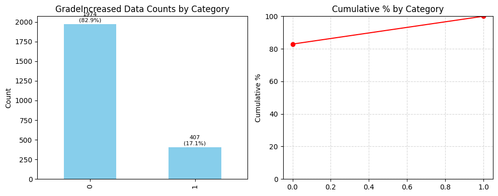

```
📊 Summary Statistics for GradeIncreased Data
==================================================
Mode   : 0
Median : 0
```

```python
col = 'GradeIncreased'

univariate_ordinal_analysis(drivers[col], f"{col} Data")
```

83% of drivers have had no increase in their grade for last 2 yrs.

### Churn

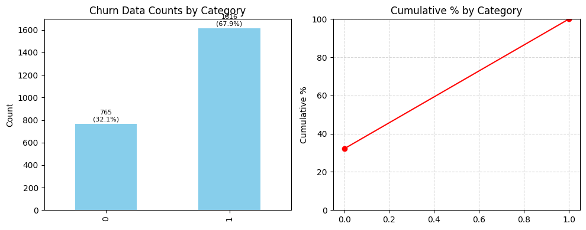

```
📊 Summary Statistics for Churn Data
==================================================
Mode   : 1
Median : 1
```

```python
col = 'Churn'

univariate_ordinal_analysis(drivers[col], f"{col} Data")
```

68% of drivers have churned over the past years.

We have imbalanced data.

### EmploymentAge

```
Mean value is 14.06 with 50% of data lying between 3.0 and 16.0
There are 284 outliers. 0 outliers are on lower side and 284 outliers are on upper side
```

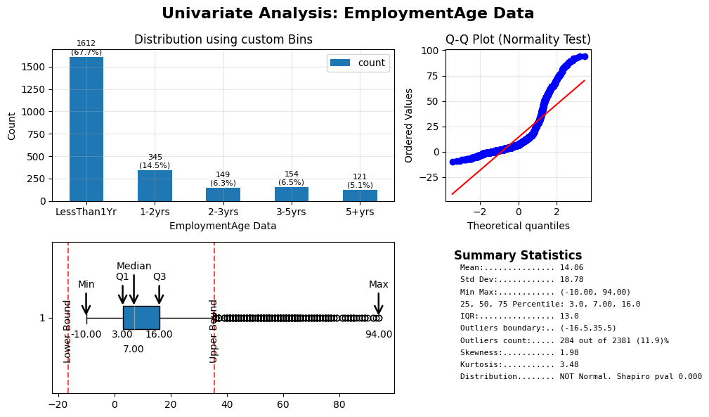

```python
col = 'EmploymentAge'

bins = [float('-inf'), 12, 24, 36, 60, float('inf')]
labels = ['LessThan1Yr', '1-2yrs', '2-3yrs','3-5yrs', '5+yrs']
univariate_numerical_analysis(drivers[col], f"{col} Data", {"bins":bins, "labels":labels})
```

67% of drivers have joined in last year

82% of drivers joined less than 2 yrs back

95% of drivers joined less than 5 yrs back and only 5% of drivers are those that have stayed with the company for more than 5 yrs. This points to a huge attrition rate. Surely attrition is a problem in the company.

### City

- We established earlier that no driver has changed their city.
- Hence we can use driver level dataframe to analyse the cities.

```python
col = 'City'
drivers_by_city = drivers[col].value_counts()
print(f'We have {len(drivers_by_city)} cities')
print(f'On average, each city has {np.floor(drivers_by_city.mean())} drivers')
top_city = drivers_by_city.idxmax()
top_count = drivers_by_city.max()
total_count = drivers_by_city.sum()
percentage = (top_count / total_count) * 100

print(f"City with maximum drivers: {top_city} ({top_count} drivers, {percentage:.2f}% of total)")
```

```
We have 29 cities
On average, each city has 82.0 drivers
City with maximum drivers: C20 (152 drivers, 6.38% of total)
```

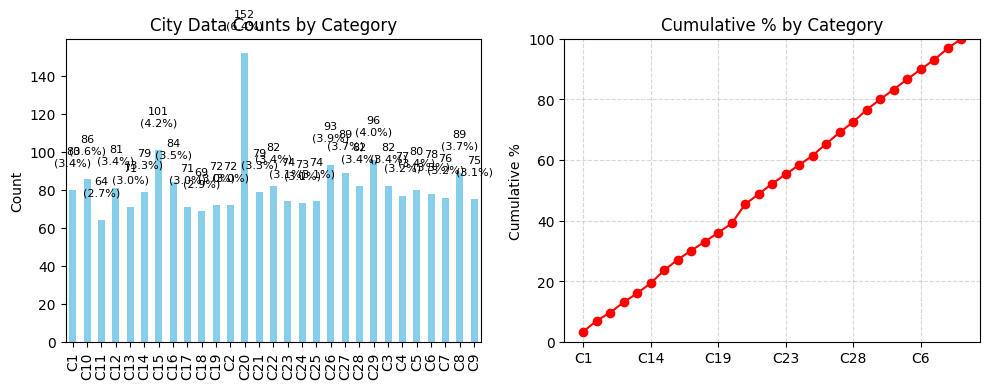

```
📊 Summary Statistics for City Data
==================================================
Mode   : C20
Median : C22
```

```python
univariate_ordinal_analysis(drivers[col], f"{col} Data")
```

We have 29 cities

On average, each city has 82.0 drivers

City with maximum drivers: C20 (152 drivers, 6.38% of total)

## 3.2 Multivariate Analysis

#### Reusable helper function for ANOVA/KRUSKAL to compare categorical and numerical columns

```python
#Reusable function
#It will perform Anova or Kruksal based on input
#It will generate all groups and then perform the specific test.
# log = compact, detailed, compactNoDiagram, detailedNoDiagram
# We can pass a third column to act as hue. This makes it a trivariate analysis.

import pingouin as pg


def perform_anova_kruskal(data,numerical_column,categorical_column, test, log="detailed", hueColumn=None):
    #η² for kruskal, ε² for anova
    def interpret_effect(size,test="anova"):
        if(test=='anova'):
            metric="ε²"
        else:
            metric="η²"
        effectMetric = f'{metric}={size:.2f}'
        if(p_value<0.05):
            if size < 0.01:
                effect = f'Even though {categorical_column} values vary across {numerical_column} groups (enough to be statistically significant {test} p_value={p_value}), {numerical_column} itself doesn’t meaningfully influence {categorical_column} — the effect is too small ({effectMetric}) to matter in practical terms.'
            elif size < 0.06:
                effect = f'{categorical_column} values vary across {numerical_column} groups (enough to be statistically significant {test} p_value={p_value}), {numerical_column} influence on {categorical_column} is considered small ({effectMetric})'
            elif size < 0.14:
                effect = f'{categorical_column} values vary across {numerical_column} groups (enough to be statistically significant {test} p_value={p_value}), {numerical_column} does have a medium influence on {categorical_column} ({effectMetric})'
            else:
                effect = f'{categorical_column} values vary across {numerical_column} groups (enough to be statistically significant {test} p_value={p_value}), {numerical_column} has a large influence on {categorical_column} ({effectMetric})'
        else:
            if size < 0.01:
                effect = f'{categorical_column} values do not vary across {numerical_column} groups (statistically insignificant {test} p_value={p_value}), which is also confirmed from effect size which is too small ({effectMetric}) to matter in practical terms.'
            elif size < 0.06:
                effect = f'{categorical_column} values do not vary across {numerical_column} groups (statistically insignificant {test} p_value={p_value}), which is also confirmed from effect size which is small ({effectMetric}) to matter in practical terms.'
            elif size < 0.14:
                effect = f'{categorical_column} values do not vary across {numerical_column} groups (statistically insignificant{test} p_value={p_value}), {numerical_column} does have a medium influence on {categorical_column} ({effectMetric})'
            else:
                effect = f'{categorical_column} values vary slightly across {numerical_column} groups (statistically insignificant {test} p_value={p_value}), {numerical_column} has a large influence on {categorical_column} ({effectMetric})'
        return effect, effectMetric



    # Group data by category and extract numerical values
    groups = [group[numerical_column].values for _, group in data.groupby(categorical_column, observed=True)]
    p_value=0
    # li="<li>"
    li=""
    Ho=Ha=HaDetail=HaDetail=effectDesc=""
    #Null Hypothesis=
    Ho=f"{li}{categorical_column} and {numerical_column} are independent. Medians of groups of {numerical_column} based on {categorical_column} are same"
    HoDetail=f"{li} In simple words, there’s no substantial {numerical_column} difference across {categorical_column} values"
    #Alternate Hypothesis
    Ha=f"{li}{categorical_column} and {numerical_column} are DEPENDENT. Medians of groups of {numerical_column} based on {categorical_column} are different"
    HaDetail=f"{li} In simple words, there’s substantial {numerical_column} difference across {categorical_column} values"

    if(test=='kruskal'):


        # Perform Kruskal-Wallis Test
        H, p_value  = stats.kruskal(*groups)

        k = len(groups)
        n = len(data)

        # Effect sizes
        epsilon_squared = (H - k + 1) / (n - k)
        effectDesc,effectMetric = interpret_effect(epsilon_squared,"kruskal")

        if(log=="detailed"):
            print(f'Ho = {Ho}')
            print(f'Ha = {Ha}')
            print(f'Kruskal-Wallis Result:{H},{p_value}')
            print(f'Effect Size: {effectMetric}')


    if(test=='anova'):
        # Perform Anova Test
        #anova_result = stats.f_oneway(*groups)
        # p_value= anova_result.pvalue

        #Using pingouin as this gives eta square value too.
        aov = pg.anova(data=data, dv=numerical_column, between=categorical_column)
        # Extract p-value and eta-squared
        p_value = aov['p-unc'].values[0]
        eta_squared = aov['np2'].values[0]  # np2 is partial eta-squared (same as eta-squared for one-way ANOVA)
        effectDesc,effectMetric = interpret_effect(eta_squared)


        if(log=="detailed"):
            print(f'Ho = {Ho}')
            print(f'Ha = {Ha}')
            print("ANOVA Result:", p_value)
            print(f'Effect Size: {effectMetric}')

    if(p_value<0.05):
        if(log=="detailed"):
            print(f"Reject Null Hypothesis. Alternate Hypothesis '{Ha}{HaDetail}' is True, p-value:{p_value:.2f}.\n{effectDesc}")

        else:
            print(f'{Ha}(p:{p_value:.2f}), {effectDesc}')



    else:
        if(log=="detailed"):
            print(f"Fail to Reject Null Hypothesis. Null Hypothesis '{Ho}{HoDetail}' is True, p-value:{p_value:.2f}")
        else:
            print(f'{Ho}(p:{p_value:.2f})')

    if(log=="detailed"):
        print()

    if("NoDiagram" not in log):
        # We can also do visualization
        fig, ax = plt.subplots(nrows=1, ncols=3, figsize=(15,5))
        sns.boxplot(data=data, y=numerical_column, x=categorical_column, ax=ax[0],hue=hueColumn)
        ax[0].set_ylabel(numerical_column)

        if(hueColumn is not None):
            df_analysis = data.groupby([categorical_column, hueColumn], as_index=False)[numerical_column].mean()
            sns.barplot(data=df_analysis, x=categorical_column, y=numerical_column, ax=ax[1], hue=hueColumn)
        else:
            df_analysis = data.groupby([categorical_column], as_index=False)[numerical_column].mean()
            sns.barplot(data=df_analysis, x=categorical_column, y=numerical_column, ax=ax[1])
        ax[1].set_xlabel(categorical_column)
        ax[1].set_ylabel(numerical_column)
        ax[1].set_title(f'Average {numerical_column} by {categorical_column}')

        sns.kdeplot(data=data, x=numerical_column, hue=categorical_column, ax=ax[2])
        ax[2].set_title(f"Kdeplot for {numerical_column} by {categorical_column}")
        plt.show()
        if(log=='detailed'):
            print(df_analysis)
```

#### Reusable helper function for chi square independence test for comparing categorical columns

```python
from scipy.stats import chi2_contingency



def perform_chi_square_test(df, col1, col2, alpha=0.05,log="detailed"):
    """
    Perform Chi-square test on two categorical columns from a DataFrame
    Also checks the Cramer's V value to establish if the association is of practical significance or only statistical.

    Parameters:
    df: pandas DataFrame
    col1: string, name of first categorical column
    col2: string, name of second categorical column
    alpha: float, significance level (default 0.05)

    Returns:
    dict with test results
    """
    li="<li>"
    # Create contingency table
    contingency_table = pd.crosstab(df[col1], df[col2])


    # Perform chi-square test
    Ho=f"{li}{col1} and {col2} are independent."
    Ha=f"{li}{col1} and {col2} are DEPENDENT"
    chi2_stat, p_value, dof, expected = chi2_contingency(contingency_table)

    # Compute effect size (Cramér's V)
    n = contingency_table.sum().sum()
    phi2 = chi2_stat / n
    r, k = contingency_table.shape
    cramers_v = (phi2 / min(k-1, r-1)) ** 0.5

    # p-value Interpretation
    if p_value < 0.05:
        relation = "Dependent (Significant)"
    else:
        relation = "Independent (Not significant)"


    # Cramer V Effect size Interpretation
    if cramers_v < 0.1:
        effectDesc = f"association is Negligible(CramersV={cramers_v:.2f})"
    elif cramers_v < 0.3:
        effectDesc = f"association is Weak(CramersV={cramers_v:.2f})"
    elif cramers_v < 0.5:
        effectDesc = f"association is Moderate(CramersV={cramers_v:.2f})"
    else:
        effectDesc = f"association is Strong(CramersV={cramers_v:.2f})"

    # Results
    results = {
        'chi2_statistic': chi2_stat,
        'p_value': p_value,
        'degrees_of_freedom': dof,
        'expected_frequencies': expected,
        'contingency_table': contingency_table,
        'significant': (p_value < alpha)
    }

    # Print results
    if("detailed" in log):
        print("Contingency Table:")
        print(contingency_table)
        print("\n")
        print(f"Chi-square Test Results:")
        print(f"Chi-square statistic: {chi2_stat:.4f}")
        print(f"p-value: {p_value:.4f}")
        print(f"Degrees of freedom: {dof}")
        print(f"Significant at α={alpha}: {'Yes' if results['significant'] else 'No'}")

    if results['significant']:
        if("detailed" in log):
            print(f"Reject Null Hypothesis. Alternate Hypothesis '{Ha}' is True, p-value:{results['p_value']}. However, {effectDesc}")
        else:
            print(f'{Ha}(p:{results['p_value']:.2f}), however {effectDesc}')
    else:
        if("detailed" in log):
            print(f"Fail to Reject Null Hypothesis. Null Hypothesis '{Ho}' is True, p-value:{results['p_value']}")
        else:
              print(f'{Ho}(p:{results['p_value']:.2f})')

    if("noplot" not in log):
        # We create two crosstabs
        crossNormalized12 = pd.crosstab(df[col1], df[col2], normalize='index') * 100
        crossNormalized21 = pd.crosstab(df[col2], df[col1], normalize='index') * 100

        # Create 1x2 subplot figure
        fig, axes = plt.subplots(1, 2, figsize=(12, 5))

        colors = [
            "salmon", "skyblue",
            "lightgreen", "gold", "orchid", "coral", "khaki",
            "plum", "turquoise", "lightsteelblue", "tan", "lightpink",
            "mediumseagreen", "wheat", "lightsalmon", "aquamarine",
            "thistle", "palegoldenrod", "powderblue", "peru", "lightcyan",
            "violet", "darkseagreen", "peachpuff", "mistyrose"
        ]
        # determine how many categories you have
        num_categories = len(crossNormalized12.columns)

        # now slice the colors list accordingly
        color_list = colors[:num_categories]
        # --- First Plot: Col2 by Col1 ---
        bars = crossNormalized12.plot(kind='bar', stacked=False, ax=axes[0], color=color_list)
        axes[0].set_title(f"{col2} by {col1}")
        axes[0].set_ylabel(f"Percentage of {col2}")
        axes[0].set_xlabel(col1)
        axes[0].legend(title=col2)
        axes[0].tick_params(axis='x', rotation=0)
        annotate_bars(bars,'%.1f%%')

        # --- Second Plot: Col1 by Col2 ---
        bars = crossNormalized21.plot(kind='bar', stacked=False, ax=axes[1], color=color_list)
        axes[1].set_title(f"{col1} by {col2}")
        axes[1].set_ylabel(f"Percentage of {col1}")
        axes[1].set_xlabel(col2)
        axes[1].legend(title=col1)
        axes[1].tick_params(axis='x', rotation=0)
        annotate_bars(bars,'%.1f%%')
        plt.show()

    if("detailed" in log):
        print("="*50)
```

#### Reusable helper function for checking relation between two numerical columns and an optional categorical column.

```python
def numerical_numerical_analysis(df, x, y, hue=None, bins=5, figsize=(14, 5)):
    """
    Create side-by-side scatter and binned mean plots for two numerical columns.
    Also prints Pearson and Spearman correlation coefficients.

    Parameters:
        df (pd.DataFrame): Input dataframe
        x (str): X-axis numerical column
        y (str): Y-axis numerical column
        hue (str, optional): Optional hue column (categorical/numeric)
        bins (int): Number of quantile bins for x-axis
        figsize (tuple): Overall figure size (width, height)
    """

    # --- Compute Correlations ---
    pearson_corr = df[x].corr(df[y], method='pearson')
    spearman_corr = df[x].corr(df[y], method='spearman')

    print(f"🔹 Pearson correlation between {x} and {y}: {pearson_corr:.3f}")
    print(f"🔹 Spearman correlation between {x} and {y}: {spearman_corr:.3f}\n")

    # --- Prepare binned data ---
    df = df.copy()
    df[f'{x} bin'] = pd.qcut(df[x], q=bins, duplicates='drop')
    binned_means = df.groupby(f'{x} bin')[y].mean().reset_index()

    # --- Set up 1x2 layout ---
    fig, axes = plt.subplots(1, 2, figsize=figsize)

    # --- Scatter Plot ---
    sns.scatterplot(data=df, x=x, y=y,hue=hue, alpha=0.7, ax=axes[0])
    sns.regplot(data=df, x=x, y=y, scatter=False, color='red', ci=None, ax=axes[0])
    axes[0].set_title(f"Scatter: {y} vs {x}\n(Pearson: {pearson_corr:.2f}, Spearman: {spearman_corr:.2f})")

    # --- Binned Mean Plot ---
    sns.barplot(data=binned_means, x=f'{x} bin', y=y, color='skyblue', ax=axes[1])
    axes[1].set_title(f"Mean {y} per {x}-bin ({bins} quantiles)")
    axes[1].tick_params(axis='x', rotation=45)

    # --- Layout adjustments ---
    plt.tight_layout()
    plt.show()
```

```python
numerical_columns=['Driver_ID', 'Age', 'Gender', 'City', 'Education_Level',
       'Dateofjoining', 'LastWorkingDate', 'Joining Designation', 'Grade',
       'Total Business Value', 'Quarterly Rating', 'IncomeCAGR', 'IncomeLast',
       'IncomeIncreased', 'GradeIncreased', 'RatingMean', 'RatingTrend',
       'RatingTrendCode', 'Ratings', 'EmploymentAge', 'TBVCategory']

# We established during univariate analysis that none of the numerical columns are normal.
# So ANOVA cannot be used
# We shall use Kruksal Wallis test for all the comparisons, therefore.
test= 'kruskal'

categorical_column = 'Churn'
```

### 3.2.1 Age and Churn

```
Ho = Churn and Age are independent. Medians of groups of Age based on Churn are same
Ha = Churn and Age are DEPENDENT. Medians of groups of Age based on Churn are different
Kruskal-Wallis Result:16.68680718104635,4.408652546642178e-05
Effect Size: η²=0.01
Reject Null Hypothesis. Alternate Hypothesis 'Churn and Age are DEPENDENT. Medians of groups of Age based on Churn are different In simple words, there’s substantial Age difference across Churn values' is True, p-value:0.00.
Even though Churn values vary across Age groups (enough to be statistically significant kruskal p_value=4.408652546642178e-05), Age itself doesn’t meaningfully influence Churn — the effect is too small (η²=0.01) to matter in practical terms.
```

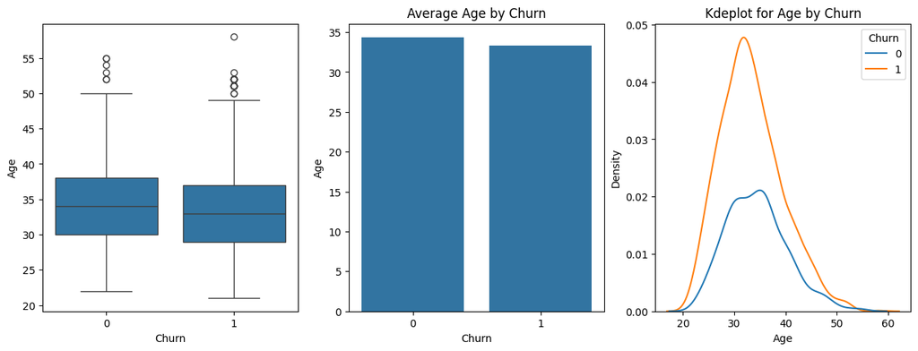

```
   Churn        Age
0      0  34.349020
1      1  33.337871
```

```python
perform_anova_kruskal(drivers,numerical_column='Age', categorical_column='Churn', test=test,log="detailed")
```

Even though Churn rates vary across Age groups (enough to be statistically significant kruskal p_value=4.408652546642178e-05), Age itself doesn’t meaningfully influence Churn — the effect is too small (η²=0.01) to matter in practical terms.

```python
drivers.columns
```

```
Index(['Driver_ID', 'Age', 'Gender', 'City', 'Education_Level',
       'Dateofjoining', 'LastWorkingDate', 'Joining Designation', 'Grade',
       'Total Business Value', 'Quarterly Rating', 'IncomeCAGR', 'IncomeLast',
       'IncomeIncreased', 'GradeIncreased', 'RatingMean', 'RatingTrend',
       'RatingTrendCode', 'Ratings', 'Churn', 'EmploymentAge'],
      dtype='object')
```

```
Mean value is 33.34 with 50% of data lying between 29.0 and 37.0
There are 16 outliers. 0 outliers are on lower side and 16 outliers are on upper side
```

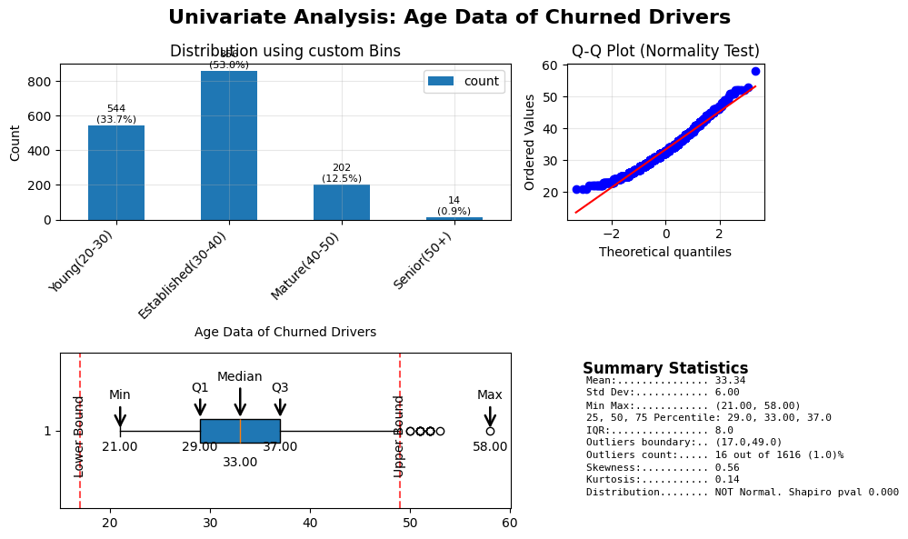

```
Mean value is 34.35 with 50% of data lying between 30.0 and 38.0
There are 6 outliers. 0 outliers are on lower side and 6 outliers are on upper side
```

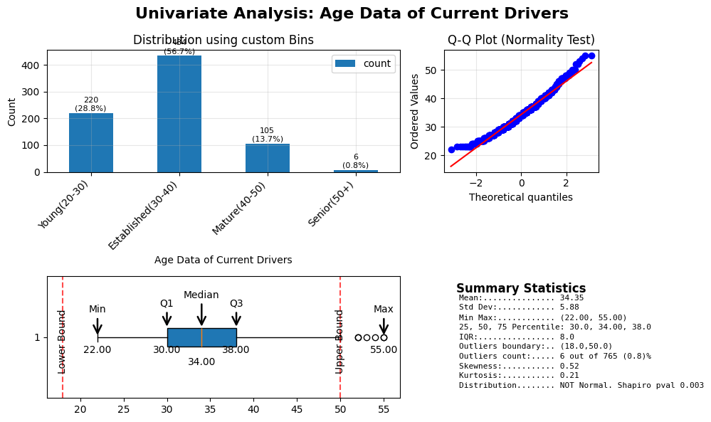

```python
driversChurned = drivers.query('Churn==1')
driversCurrent = drivers.query('Churn==0')
col = 'Age'

bins = [float('-inf'),     30,             40,      50,       float('inf')]
labels = [          'Young(20-30)', 'Established(30-40)', 'Mature(40-50)','Senior(50+)']

univariate_numerical_analysis(driversChurned[col], f"{col} Data of Churned Drivers", {"bins":bins, "labels":labels})
univariate_numerical_analysis(driversCurrent[col], f"{col} Data of Current Drivers", {"bins":bins, "labels":labels})
```